# Version comparison: Program-Area / Planning-Area scores

- Show All Code
- Hide All Code
- View Source

Parameterized report — overall composite and every component score, two releases side by side

Published

2026-11-03

> **Not a pipeline stage** — a standalone, parameterized *report* (no `msens:` target block, so `tar_make()` never runs it). Render it on demand for any two release versions whose `sdm.duckdb` are on disk. The reusable comparison **core lives in `msens`** (`zone_scored_flds`, `zone_scores`, `zone_crosswalk`, `zone_score_delta`, `score_delta`, `score_delta_summary`, `assert_within_tolerance`) so this notebook only *orchestrates* — the math is unit-tested in `msens/tests/testthat/test-validate.R` and can’t drift from what’s reported here.

> ```r
> # render with version suffixes in the output filename (see scripts/render_compare.R):
> source("scripts/render_compare.R"); render_compare("v6", "v9")   # -> _output/compare_versions_v6_vs_v9.html
> # or from the shell:
> Rscript scripts/render_compare.R v6 v9
> ```

> **What is compared.** Scores on each release’s **principal reporting unit** — the 20 BOEM **Program Areas** (v2 onward) or, for a release that scored none, the 36 **Planning Areas** (v1). Ecoregions and subregions are deliberately not reported here. When the two releases used different units, zones are compared **only where they are the same polygon** (`msens::zone_crosswalk()`, intersection over union ≥ 0.999, computed from the polygons at render time); everything else — a Program Area that is a *subset* of a Planning Area, a Planning Area with no Program Area — is listed **adjacent, not compared**, exactly as components present in only one release (v6’s `other`, v8+’s `primary_producer`) are. The overall composite and each **component** it averages (`extrisk_{category}_ecoregion_rescaled` + `primprod_ecoregion_rescaled`) are shown. `Δ = B − A`.

## 1 Setup

```r
librarian::shelf(DBI, duckdb, dplyr, DT, ggplot2, glue, htmltools, knitr, leaflet, purrr,
                 rmapshaper, scales, sf, tidyr, MarineSensitivity/msens, quiet = TRUE)
source(here::here("libs/paths.R"))

va <- params$version_a
vb <- params$version_b
mk <- params$metric_key
stopifnot(va != vb)

# resolve each version's sdm.duckdb by swapping the version segment of the configured path
sdm_for <- function(v) sub(glue("/{ver}/"), glue("/{v}/"), path.expand(sdm_db))
db_a <- sdm_for(va); db_b <- sdm_for(vb)
stopifnot(file.exists(db_a), file.exists(db_b))

con_a <- dbConnect(duckdb(), db_a, read_only = TRUE)
con_b <- dbConnect(duckdb(), db_b, read_only = TRUE)

va_col <- glue("score_{va}"); vb_col <- glue("score_{vb}")

# the principal reporting unit each release actually scored: Program Areas if it has them, else
# Planning Areas (v1); never ecoregions or subregions
UNITS <- c(programarea = "programarea_key", planarea = "planarea_key")
unit_of <- function(con, v) {
  flds <- msens::zone_scored_flds(con, mk)
  u <- UNITS[UNITS %in% flds]
  if (!length(u)) stop(glue("{v}: no Program-Area or Planning-Area zones carry `{mk}` (has: ",
                            "{paste(flds, collapse = ', ')})"))
  names(u)[1]
}
unit_a <- unit_of(con_a, va); unit_b <- unit_of(con_b, vb)
fld_a  <- UNITS[[unit_a]];    fld_b  <- UNITS[[unit_b]]
unit_label <- c(programarea = "Program Area", planarea = "Planning Area")

cat(glue("Comparing **{va}** (A) ← → **{vb}** (B)  \n",
         "- A ({va}): `{db_a}` — scored on **{unit_label[[unit_a]]}s** (`{fld_a}`)  \n",
         "- B ({vb}): `{db_b}` — scored on **{unit_label[[unit_b]]}s** (`{fld_b}`)  \n",
         "- composite metric: `{mk}`\n"))
```

```
Comparing **v10** (A) ← → **v11** (B)
- A (v10): `/Users/bbest/_big/msens/derived/v10/sdm.duckdb` — scored on **Program Areas** (`programarea_key`)
- B (v11): `/Users/bbest/_big/msens/derived/v11/sdm.duckdb` — scored on **Program Areas** (`programarea_key`)
- composite metric: `score_extriskspcat_primprod_ecoregionrescaled_equalweights`
```

### 1.1 Zone polygons

The choropleths and the crosswalk need each unit’s geometry. It is resolved from the derived tree by **content**, not by filename: every `ply_{unit}s_*.gpkg` under `dir_derived` is fingerprinted with `msens::zone_geom_hash()` and the first whose hash equals that unit’s entry in `data/zone_sets.csv` is used — so the map can never silently draw a different vintage than the scores were computed on.

```r
zone_sets <- readr::read_csv(here::here("data/zone_sets.csv"), show_col_types = FALSE)

resolve_ply <- function(unit) {
  zs <- zone_sets |> filter(zone_type == unit)
  stopifnot(nrow(zs) >= 1)
  zs <- zs[1, ]
  cands <- list.files(path.expand(dir_derived), pattern = glue("^ply_{unit}s_.*\\.gpkg$"),
                      recursive = TRUE, full.names = TRUE)
  for (f in cands) {
    x <- sf::st_read(f, quiet = TRUE)
    h <- tryCatch(msens::zone_geom_hash(x, zone_type = unit)$geom_hash, error = function(e) NA)
    if (identical(h, zs$geom_hash)) {
      key <- UNITS[[unit]]; nm <- glue("{unit}_name")
      x <- x |>
        transmute(zone_key = as.character(.data[[key]]), zone_name = .data[[nm]],
                  region = if ("region_key" %in% names(x)) region_key else NA_character_,
                  hint   = if ("planarea_key" %in% names(x) && unit != "planarea") planarea_key
                           else NA_character_) |>
        st_make_valid()
      attr(x, "src") <- f; attr(x, "zone_set_key") <- zs$zone_set_key
      return(x)
    }
  }
  stop(glue("no ply_{unit}s_*.gpkg under {dir_derived} matches geom_hash {zs$geom_hash} ",
            "({zs$zone_set_key}); candidates: {paste(cands, collapse = ', ')}"))
}
ply_a <- resolve_ply(unit_a)
ply_b <- if (unit_b == unit_a) ply_a else resolve_ply(unit_b)

for (p in unique(list(ply_a, ply_b)))
  cat(glue("- `{sub(path.expand(dir_derived), '', attr(p, 'src'))}` — {attr(p, 'zone_set_key')}, ",
           "{nrow(p)} zones\n\n"))
```

```
- `/v10/ply_programareas_2026_v10.gpkg` — programarea_2026-01, 20 zones
```

### 1.2 Crosswalk: which zones are compared

```r
if (unit_a == unit_b) {
  xw <- tibble(key_a = ply_a$zone_key, key_b = ply_a$zone_key, iou = 1, identical = TRUE)
} else {
  hint <- if (!all(is.na(ply_b$hint))) "hint" else NULL
  xw <- msens::zone_crosswalk(ply_a, ply_b, "zone_key", "zone_key", hint = hint) |> as_tibble()
}
# key_a -> key_b for the compared (identical) pairs; every other zone is one-sided
xw_id <- xw |> filter(identical)
stopifnot(!any(duplicated(xw_id$key_a)), !any(duplicated(xw_id$key_b)))
map_ab <- setNames(xw_id$key_b, xw_id$key_a)

only_a_zones <- setdiff(ply_a$zone_key, xw_id$key_a)
only_b_zones <- setdiff(ply_b$zone_key, xw_id$key_b)

# why a one-sided zone is not compared
why_not <- function(k, side) {
  if (unit_a == unit_b) return(glue("not in {if (side == 'a') vb else va}"))
  r <- if (side == "a") xw |> filter(grepl(paste0("(^|,)", k, "(,|$)"), key_a)) else xw |> filter(key_b == k)
  if (!nrow(r)) return(glue("no {unit_label[[if (side == 'a') unit_b else unit_a]]} covers it"))
  glue("partial overlap only — {if (side == 'a') r$key_b[1] else r$key_a[1]} (IoU {max(r$iou)})")
}

cat(glue("- {unit_label[[unit_a]]}s in {va}: **{nrow(ply_a)}**; {unit_label[[unit_b]]}s in {vb}: ",
         "**{nrow(ply_b)}**  \n",
         "- zones compared (same polygon): **{nrow(xw_id)}**  \n",
         "- only in {va}, listed not compared: **{length(only_a_zones)}**",
         if (length(only_a_zones)) glue(" ({paste(only_a_zones, collapse = ', ')})") else "", "  \n",
         "- only in {vb}, listed not compared: **{length(only_b_zones)}**",
         if (length(only_b_zones)) glue(" ({paste(only_b_zones, collapse = ', ')})") else "", "\n"))
```

```
- Program Areas in v10: **20**; Program Areas in v11: **20**
- zones compared (same polygon): **20**
- only in v10, listed not compared: **0**
- only in v11, listed not compared: **0**
```

```r
if (unit_a != unit_b)
  knitr::kable(xw |> arrange(desc(identical), key_b),
               caption = glue("Every candidate pair, {unit_label[[unit_a]]} ({va}) → ",
                              "{unit_label[[unit_b]]} ({vb}); only `identical` pairs are compared"))
```

```r
# one drawing layer: compared zones (B geometry, both keys), B-only zones, A-only zones (A geometry)
zone_names <- bind_rows(
  st_drop_geometry(ply_b) |> transmute(key_b = zone_key, name_b = zone_name, region_b = region),
  tibble(key_b = character(), name_b = character(), region_b = character()))
ply_draw <- bind_rows(
  ply_b |> filter(zone_key %in% xw_id$key_b) |>
    mutate(key_b = zone_key, key_a = names(map_ab)[match(zone_key, map_ab)], status = "compared"),
  ply_b |> filter(zone_key %in% only_b_zones) |>
    mutate(key_b = zone_key, key_a = NA_character_, status = glue("only in {vb}")),
  ply_a |> filter(zone_key %in% only_a_zones) |>
    mutate(key_b = NA_character_, key_a = zone_key, status = glue("only in {va}"))) |>
  mutate(zone_key = coalesce(key_b, key_a),
         label = ifelse(status == "compared" & unit_a != unit_b, glue("{key_a} → {key_b}"), zone_key)) |>
  select(zone_key, key_a, key_b, zone_name, region, status, label)
# ~450k vertices are far more than a choropleth of a few dozen polygons needs
ply_s <- rmapshaper::ms_simplify(ply_draw, keep = 0.02, keep_shapes = TRUE) |> st_make_valid()
# Leaflet: shift to 0–360 so the Aleutian polygons that straddle the antimeridian draw as one
ply_l <- st_shift_longitude(ply_s)
bb_l  <- st_bbox(ply_l)
names_draw <- st_drop_geometry(ply_draw) |> select(zone_key, key_a, key_b, zone_name, region, status)
cat(glue("drawing {nrow(ply_draw)} zones ({sum(ply_draw$status == 'compared')} compared); simplified ",
         "{nrow(st_coordinates(ply_draw))} → {nrow(st_coordinates(ply_s))} vertices"))
```

```
drawing 20 zones (20 compared); simplified 452193 → 9776 vertices
```

### 1.3 Report helpers

Presentation only — every number comes from the `msens` core.

```r
# diverging background for a Δ column: n colours need n-1 cut points
div_style <- function(x, n = 8) {
  lim <- max(abs(x), na.rm = TRUE); if (!is.finite(lim) || lim == 0) lim <- 1
  list(brks = seq(-lim, lim, length.out = n + 1)[2:n],
       cols = colorRampPalette(c("#e8590c", "#ffffff", "#20c997"))(n))
}

# choropleth: three base layers (A score, B score, Δ) on one map; hover shows all three.
# `d` is keyed by the B zone key for compared zones; one-sided zones come from the long frames.
zone_map <- function(d, sa, sb, title) {
  x <- ply_l |>
    left_join(d |> select(key_b = zone_key, a = all_of(va_col), b = all_of(vb_col), delta), by = "key_b") |>
    left_join(sa |> select(key_a = zone_key, a1 = score), by = "key_a") |>
    left_join(sb |> select(key_b = zone_key, b1 = score), by = "key_b") |>
    mutate(a = coalesce(a, a1), b = coalesce(b, b1),
           delta = ifelse(status == "compared", delta, NA_real_))
  rng <- range(c(x$a, x$b), na.rm = TRUE)
  lim <- max(abs(x$delta), na.rm = TRUE); if (!is.finite(lim) || lim == 0) lim <- 1
  pal_s <- colorNumeric("viridis", domain = rng, na.color = "#00000000")
  pal_d <- colorNumeric(c("#e8590c", "#f8f9fa", "#20c997"), domain = c(-lim, lim), na.color = "#00000000")
  fmt <- function(v, f = "%.2f") ifelse(is.na(v), "—", sprintf(f, v))
  lbl <- glue("<b>{x$label}</b> {x$zone_name}<br/>",
              "{va}: {fmt(x$a)}<br/>{vb}: {fmt(x$b)}<br/>Δ: {fmt(x$delta, '%+.2f')}",
              "{ifelse(x$status == 'compared', '', paste0('<br/><i>', x$status, ' — not compared</i>'))}") |>
    lapply(HTML)
  dash <- ifelse(x$status == "compared", "", "6 4")   # one-sided zones: dashed outline
  poly <- function(m, fill, grp) {
    m |> addPolygons(
      fillColor = fill, fillOpacity = 0.75, color = "#555", weight = 0.7, opacity = 0.8,
      dashArray = dash, label = lbl, group = grp,
      highlightOptions = highlightOptions(weight = 2, color = "#000", bringToFront = TRUE))
  }
  # Esri's grey canvas needs no API key (CARTO's basemaps now do)
  leaflet(x, options = leafletOptions(worldCopyJump = FALSE)) |>
    addProviderTiles("Esri.WorldGrayCanvas") |>
    fitBounds(bb_l[["xmin"]], bb_l[["ymin"]], bb_l[["xmax"]], bb_l[["ymax"]]) |>
    poly(~pal_s(a), va) |>
    poly(~pal_s(b), vb) |>
    poly(~pal_d(delta), "Δ") |>
    addLegend(pal = pal_s, values = c(x$a, x$b), title = glue("{title}<br/>score ({va}, {vb})"),
              position = "bottomleft", na.label = "") |>
    addLegend(pal = pal_d, values = c(-lim, lim), title = glue("{title}<br/>Δ {vb} − {va}"),
              position = "bottomright", na.label = "") |>
    addLayersControl(baseGroups = c(va, vb, "Δ"), position = "topright",
                     options = layersControlOptions(collapsed = FALSE))
}

# sortable table of the compared zones: keys, both scores, Δ and Δ %, coloured on Δ
zone_table <- function(d, caption) {
  t <- d |>
    left_join(names_draw |> filter(status == "compared") |> select(-status), by = c("zone_key" = "key_b")) |>
    transmute(!!glue("{unit_label[[unit_a]]} ({va})") := key_a,
              !!glue("{unit_label[[unit_b]]} ({vb})") := zone_key,
              Name = zone_name, Region = region,
              !!va := round(.data[[va_col]], 2),
              !!vb := round(.data[[vb_col]], 2),
              `Δ` = round(delta, 2),
              `Δ %` = ifelse(.data[[va_col]] != 0, round(100 * delta / .data[[va_col]], 1), NA)) |>
    arrange(desc(abs(`Δ`)))
  if (unit_a == unit_b) t <- t[-1]      # one key column when the units are the same
  ds <- div_style(t$`Δ`)
  DT::datatable(t, rownames = FALSE, caption = caption,
                options = list(pageLength = 40, dom = "t", order = list(list(ncol(t) - 2, "desc")))) |>
    DT::formatStyle("Δ", backgroundColor = DT::styleInterval(ds$brks, ds$cols))
}

# the one-sided zones, with their score in the version that has them — adjacent, not compared
adjacent_table <- function(sa, sb, caption) {
  t <- bind_rows(
    sa |> filter(zone_key %in% only_a_zones) |>
      left_join(st_drop_geometry(ply_a) |> select(zone_key, zone_name, region), by = "zone_key") |>
      transmute(version = va, unit = unit_label[[unit_a]], zone = zone_key, Name = zone_name,
                Region = region, score = round(score, 2),
                `why not compared` = vapply(zone_key, why_not, "", side = "a")),
    sb |> filter(zone_key %in% only_b_zones) |>
      left_join(st_drop_geometry(ply_b) |> select(zone_key, zone_name, region), by = "zone_key") |>
      transmute(version = vb, unit = unit_label[[unit_b]], zone = zone_key, Name = zone_name,
                Region = region, score = round(score, 2),
                `why not compared` = vapply(zone_key, why_not, "", side = "b")))
  if (!nrow(t)) return(cat("none — every zone of both releases is compared.\n"))
  DT::datatable(t, rownames = FALSE, caption = caption,
                options = list(pageLength = 40, dom = "t", order = list(list(5, "desc"))))
}

# per-metric delta from the two long score frames (A keys already mapped onto B keys)
metric_delta <- function(m) {
  msens::score_delta(
    scores_a_m |> filter(metric_key == m),
    scores_b   |> filter(metric_key == m),
    key = "zone_key", value = "score", labels = c(va, vb))
}
```

## 2 Scores

Every zone-level score of both releases is read once (`msens::zone_scores()`); A’s keys are mapped onto B’s through the crosswalk, and only the compared zones enter any delta.

```r
scores_a <- msens::zone_scores(con_a, fld = fld_a, zone_set_key = attr(ply_a, "zone_set_key"), label = va)
scores_b <- msens::zone_scores(con_b, fld = fld_b, zone_set_key = attr(ply_b, "zone_set_key"), label = vb)
scores_a_m <- scores_a |> filter(zone_key %in% names(map_ab)) |> mutate(zone_key = unname(map_ab[zone_key]))
zd <- msens::zone_score_delta(scores_a_m, scores_b |> filter(zone_key %in% xw_id$key_b), labels = c(va, vb))
cat(glue("{nrow(scores_a)} (zone × metric) rows in {va}, {nrow(scores_b)} in {vb}; ",
         "{zd$n_zones_shared} zones and {nrow(zd$by_metric)} metrics compared"))
```

```
3007 (zone × metric) rows in v10, 2969 in v11; 20 zones and 160 metrics compared
```

## 3 Overall composite score

The headline equivalence gate: the composite (score_extriskspcat_primprod_ecoregionrescaled_equalweights) per compared zone in each version.

```r
d <- metric_delta(mk)
s <- msens::score_delta_summary(d)

# soft equivalence verdict — report, never hard-stop (a report must render either way)
gate <- tryCatch(
  { msens::assert_within_tolerance(d, mean_tol = params$mean_tol, max_tol = params$max_tol); "PASS" },
  error = function(e) conditionMessage(e))

knitr::kable(
  tibble::tibble(
    metric = c("zones compared", "mean |Δ|", "max |Δ|", "RMSE", "correlation",
               "tolerance (mean / max)", "verdict"),
    value  = c(s$n, round(s$mean_abs, 3), round(s$max_abs, 3), round(s$rmse, 3),
               round(cor(d[[va_col]], d[[vb_col]]), 4),
               glue("{params$mean_tol} / {params$max_tol}"),
               ifelse(gate == "PASS", "✅ within tolerance", paste0("⚠️ ", gate)))),
  caption = glue("Composite-score equivalence, {va} → {vb}"))
```

Composite-score equivalence, v10 → v11

| metric | value |
| --- | --- |
| zones compared | 20 |
| mean \|Δ\| | 4.094 |
| max \|Δ\| | 9.648 |
| RMSE | 4.808 |
| correlation | 0.8942 |
| tolerance (mean / max) | 5 / 15 |
| verdict | ✅ within tolerance |

### 3.1 Map

Switch between **v10**, **v11** and **Δ** with the radio buttons; hover a zone for all three values. Both score layers share one colour scale so they are directly comparable. Zones with a **dashed outline** exist in one release only: they carry that release’s score in its layer and no Δ.

```r
zone_map(d, scores_a |> filter(metric_key == mk), scores_b |> filter(metric_key == mk), "Composite")
```

[interactive chart not shown]

### 3.2 Table

Click a column header to sort by zone, score or difference.

```r
zone_table(d, glue("Composite score per compared zone, {va} vs {vb}"))
```

| Program Area (v11) | Name | Region | v10 | v11 | Δ | Δ % |
| --- | --- | --- | --- | --- | --- | --- |
| SHU | Shumagin | AK | 19.39 | 29.04 | 9.65 | 49.8 |
| ALA | Aleutian Arc | AK | 30.01 | 20.77 | -9.24 | -30.8 |
| GOA | Gulf of Alaska | AK | 32.08 | 25 | -7.08 | -22.1 |
| KOD | Kodiak | AK | 22.19 | 28.92 | 6.74 | 30.4 |
| MAT | St. Matthew-Hall | AK | 24.85 | 19.46 | -5.39 | -21.7 |
| NAV | Navarin Basin | AK | 22.6 | 17.7 | -4.91 | -21.7 |
| ALB | Aleutian Basin | AK | 14.94 | 10.13 | -4.81 | -32.2 |
| NOR | Norton Basin | AK | 29.35 | 24.71 | -4.64 | -15.8 |
| GAB | GOA Program Area B | GA | 18.14 | 22.57 | 4.44 | 24.5 |
| CHU | Chukchi Sea | AK | 23.11 | 27.39 | 4.28 | 18.5 |

[output cut: 10 more lines]

### 3.3 Adjacent, not compared

```r
adjacent_table(scores_a |> filter(metric_key == mk), scores_b |> filter(metric_key == mk),
               glue("Zones present in one release only, with their composite score there"))
```

```
none — every zone of both releases is compared.
```

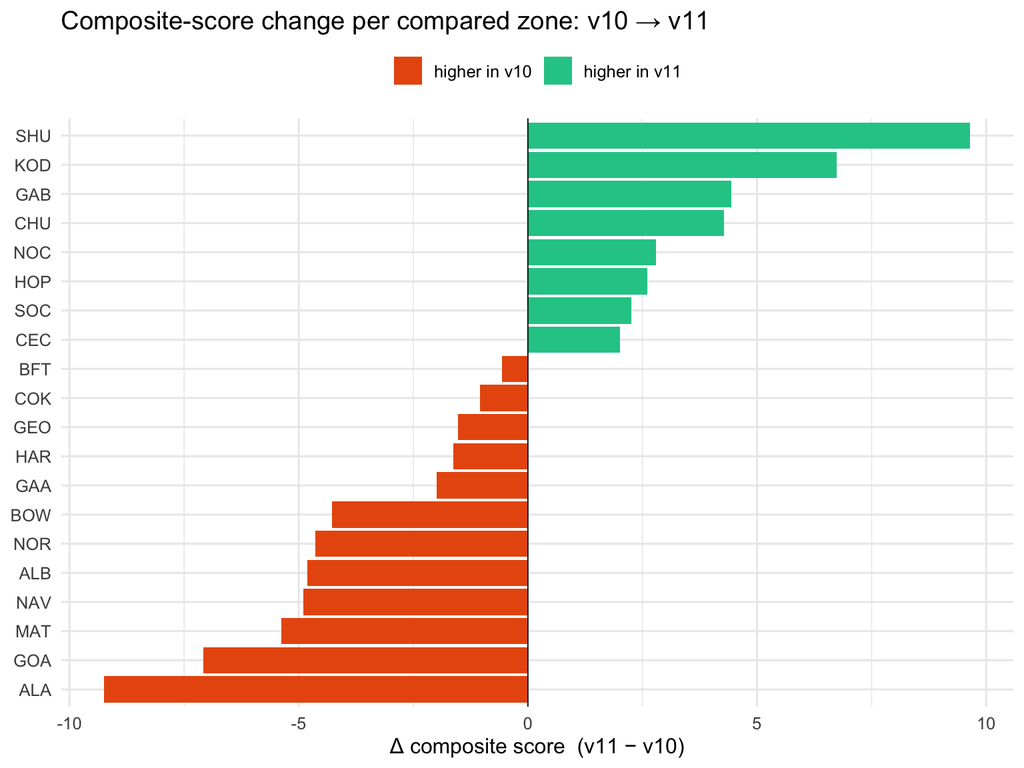

```r
d_plot <- d |>
  mutate(zone_key = factor(zone_key, levels = zone_key[order(delta)]),
         sign = ifelse(delta >= 0, glue("higher in {vb}"), glue("higher in {va}")))

ggplot(d_plot, aes(delta, zone_key, fill = sign)) +
  geom_col() +
  geom_vline(xintercept = 0, linewidth = 0.3) +
  scale_fill_manual(values = setNames(c("#20c997", "#e8590c"),
                                      c(glue("higher in {vb}"), glue("higher in {va}")))) +
  labs(x = glue("Δ composite score  ({vb} − {va})"), y = NULL, fill = NULL,
       title = glue("Composite-score change per compared zone: {va} → {vb}")) +
  theme_minimal(base_size = 12) +
  theme(legend.position = "top")
```

## 4 Component scores

`msens::zone_score_delta()` compares only shared zones and metrics and **returns what it had to drop**, so a component one release lacks is listed, never compared against nothing.

```r
is_component <- function(m) grepl("^extrisk_[a-z_]+_ecoregion_rescaled$", m) |
                            m == "primprod_ecoregion_rescaled"
comp_label <- function(m) ifelse(m == "primprod_ecoregion_rescaled", "primary productivity",
                                 sub("^extrisk_(.*)_ecoregion_rescaled$", "\\1", m))
comp_title <- function(m) tools::toTitleCase(gsub("_", " ", comp_label(m)))

comps <- zd$by_metric |>
  filter(is_component(metric_key)) |>
  mutate(component = comp_label(metric_key)) |>
  arrange(desc(mean_abs_delta))

only_a <- zd$metrics_only_a[is_component(zd$metrics_only_a)]
only_b <- zd$metrics_only_b[is_component(zd$metrics_only_b)]

cat(glue("- components compared: **{nrow(comps)}**  \n",
         "- components only in {va} (listed, not compared): ",
         if (length(only_a)) paste0("`", only_a, "`", collapse = ", ") else "none", "  \n",
         "- components only in {vb} (listed, not compared): ",
         if (length(only_b)) paste0("`", only_b, "`", collapse = ", ") else "none", "\n"))
```

```
- components compared: **8**
- components only in v10 (listed, not compared): none
- components only in v11 (listed, not compared): none
```

### 4.1 Summary by component

```r
comps |>
  transmute(component, metric_key, n = n_zones,
            !!glue("mean {va}") := round(mean_a, 2), !!glue("mean {vb}") := round(mean_b, 2),
            `mean Δ` = round(mean_delta, 2), `mean |Δ|` = round(mean_abs_delta, 2),
            `max |Δ|` = round(max_abs_delta, 2), r = round(cor, 3)) |>
  DT::datatable(rownames = FALSE, options = list(dom = "t", pageLength = 25),
                caption = glue("Per-component delta over the compared zones, {va} → {vb}, sorted by mean |Δ|"))
```

| component | metric_key | n | mean v10 | mean v11 | mean Δ | mean \|Δ\| | max \|Δ\| | r |
| --- | --- | --- | --- | --- | --- | --- | --- | --- |
| turtle | extrisk_turtle_ecoregion_rescaled | 9 | 32.46 | 47.91 | 15.44 | 27.76 | 66.69 | -0.122 |
| mammal | extrisk_mammal_ecoregion_rescaled | 20 | 50.65 | 40.76 | -9.89 | 12.72 | 29.05 | 0.761 |
| bird | extrisk_bird_ecoregion_rescaled | 20 | 37.79 | 33.21 | -4.58 | 10.94 | 27.94 | 0.847 |
| fish | extrisk_fish_ecoregion_rescaled | 20 | 23.78 | 23.79 | 0.01 | 5.43 | 22.2 | 0.889 |
| primary_producer | extrisk_primary_producer_ecoregion_rescaled | 20 | 12.36 | 16.27 | 3.92 | 3.94 | 11.34 | 0.954 |
| coral | extrisk_coral_ecoregion_rescaled | 20 | 13.66 | 13.98 | 0.33 | 1.7 | 8.53 | 0.977 |
| primary productivity | primprod_ecoregion_rescaled | 20 | 8.58 | 8.88 | 0.31 | 1.27 | 4.69 | 0.966 |
| invertebrate | extrisk_invertebrate_ecoregion_rescaled | 20 | 20.63 | 20.77 | 0.14 | 0.92 | 1.77 | 0.998 |

### 4.2 Δ by zone × component

One cell per (compared zone, component): Δ = B − A. Sort any column to find where a component moved most.

```r
comp_keys  <- comps$metric_key
comp_delta <- setNames(lapply(comp_keys, metric_delta), comp_keys)

wide <- bind_rows(
    lapply(comp_keys, function(m) comp_delta[[m]] |> transmute(zone_key, component = comp_label(m), delta)),
    d |> transmute(zone_key, component = "COMPOSITE", delta)) |>
  mutate(delta = round(delta, 2)) |>
  pivot_wider(names_from = component, values_from = delta) |>
  left_join(names_draw |> filter(status == "compared") |> select(key_b, zone_name, region), by = c("zone_key" = "key_b")) |>
  relocate(zone_key, zone_name, region, COMPOSITE) |>
  rename(Zone = zone_key, Name = zone_name, Region = region) |>
  arrange(desc(abs(COMPOSITE)))

num_cols <- names(wide)[sapply(wide, is.numeric)]
ds <- div_style(unlist(wide[num_cols]), n = 10)
DT::datatable(wide, rownames = FALSE, options = list(dom = "t", pageLength = 40, scrollX = TRUE),
              caption = glue("Δ ({vb} − {va}) per compared zone and component")) |>
  DT::formatStyle(num_cols, backgroundColor = DT::styleInterval(ds$brks, ds$cols))
```

| Zone | Name | Region | COMPOSITE | turtle | mammal | bird | fish | primary_producer | coral | primary productivity | invertebrate |
| --- | --- | --- | --- | --- | --- | --- | --- | --- | --- | --- | --- |
| SHU | Shumagin | AK | 9.65 | 66.69 | 3.22 | -2.54 | 2.06 | 3.59 | 2.82 | 0.46 | 0.87 |
| ALA | Aleutian Arc | AK | -9.24 |  | -16.58 | -15.5 | -4.11 | 7.2 | 1.19 | 2.52 | 0.79 |
| GOA | Gulf of Alaska | AK | -7.08 | -40.01 | -15.5 | -12.56 | 1.16 | 6.36 | 3.62 | -0.95 | 1.22 |
| KOD | Kodiak | AK | 6.74 | 46.85 | 0.11 | -3.35 | 1.85 | 4.11 | 3.6 | -0.49 | 1.21 |
| MAT | St. Matthew-Hall | AK | -5.39 |  | -29.05 | -18.31 | 3.01 | 6.72 | -0.49 | 1.76 | -1.34 |
| NAV | Navarin Basin | AK | -4.91 |  | -21.92 | -17.96 | 6.05 | 0.73 | -1.2 | 0.59 | -0.63 |
| ALB | Aleutian Basin | AK | -4.81 |  | -24.46 | -9.32 | -2.64 | 0.29 | 1.99 | 0.45 | -0.01 |
| NOR | Norton Basin | AK | -4.64 |  | -19.93 | -27.94 | 3.39 | 11.34 | -0.65 | 2.38 | -1.05 |
| GAB | GOA Program Area B | GA | 4.44 | -2.05 | 16.68 | 16.9 | 4.09 | -0.04 | -0.16 | 0 | 0.08 |
| CHU | Chukchi Sea | AK | 4.28 |  | 1.63 | 6.56 | 22.2 | 0 | -1.38 | -0.82 | 1.77 |

[output cut: 10 more lines]

### 4.3 Each component: map and table

**Turtle**

`extrisk_turtle_ecoregion_rescaled` — 9 zones compared; mean |Δ| 27.76, max |Δ| 66.69, r = -0.122.

[interactive chart not shown]

| Program Area (v11) | Name | Region | v10 | v11 | Δ | Δ % |
| --- | --- | --- | --- | --- | --- | --- |
| SHU | Shumagin | AK | 26.73 | 93.42 | 66.69 | 249.5 |
| KOD | Kodiak | AK | 35.81 | 82.66 | 46.85 | 130.8 |
| GOA | Gulf of Alaska | AK | 58.26 | 18.25 | -40.01 | -68.7 |
| NOC | Northern California | PA | 11.24 | 36.4 | 25.16 | 223.9 |
| CEC | Central California | PA | 14.52 | 36.55 | 22.03 | 151.7 |
| COK | Cook Inlet | AK | 29.75 | 48.13 | 18.38 | 61.8 |
| SOC | Southern California | PA | 20.8 | 36.08 | 15.28 | 73.5 |
| GAA | GOA Program Area A | GA | 59.63 | 46.29 | -13.34 | -22.4 |
| GAB | GOA Program Area B | GA | 35.43 | 33.38 | -2.05 | -5.8 |

**Mammal**

`extrisk_mammal_ecoregion_rescaled` — 20 zones compared; mean |Δ| 12.72, max |Δ| 29.05, r = 0.761.

[interactive chart not shown]

| Program Area (v11) | Name | Region | v10 | v11 | Δ | Δ % |
| --- | --- | --- | --- | --- | --- | --- |
| MAT | St. Matthew-Hall | AK | 67.5 | 38.45 | -29.05 | -43 |
| COK | Cook Inlet | AK | 90.16 | 64.06 | -26.1 | -29 |
| ALB | Aleutian Basin | AK | 47.98 | 23.52 | -24.46 | -51 |
| GEO | St. George Basin | AK | 68.79 | 45.3 | -23.49 | -34.1 |
| NAV | Navarin Basin | AK | 65.92 | 44 | -21.92 | -33.3 |
| NOR | Norton Basin | AK | 72.64 | 52.71 | -19.93 | -27.4 |
| BOW | Bowers Basin | AK | 45.78 | 26.07 | -19.71 | -43 |
| GAB | GOA Program Area B | GA | 47.78 | 64.46 | 16.68 | 34.9 |
| ALA | Aleutian Arc | AK | 35.53 | 18.95 | -16.58 | -46.7 |
| GOA | Gulf of Alaska | AK | 59.81 | 44.31 | -15.5 | -25.9 |

[output cut: 10 more lines]

**Bird**

`extrisk_bird_ecoregion_rescaled` — 20 zones compared; mean |Δ| 10.94, max |Δ| 27.94, r = 0.847.

[interactive chart not shown]

| Program Area (v11) | Name | Region | v10 | v11 | Δ | Δ % |
| --- | --- | --- | --- | --- | --- | --- |
| NOR | Norton Basin | AK | 73.94 | 46 | -27.94 | -37.8 |
| GEO | St. George Basin | AK | 52.1 | 33.5 | -18.6 | -35.7 |
| MAT | St. Matthew-Hall | AK | 64.67 | 46.36 | -18.31 | -28.3 |
| NAV | Navarin Basin | AK | 47.33 | 29.37 | -17.96 | -37.9 |
| GAB | GOA Program Area B | GA | 31.12 | 48.03 | 16.9 | 54.3 |
| ALA | Aleutian Arc | AK | 55.12 | 39.62 | -15.5 | -28.1 |
| HOP | Hope Basin | AK | 36.15 | 50.83 | 14.67 | 40.6 |
| BOW | Bowers Basin | AK | 42.36 | 28.85 | -13.52 | -31.9 |
| GOA | Gulf of Alaska | AK | 44.59 | 32.04 | -12.56 | -28.2 |
| NOC | Northern California | PA | 10.89 | 22.88 | 11.99 | 110.2 |

[output cut: 10 more lines]

**Fish**

`extrisk_fish_ecoregion_rescaled` — 20 zones compared; mean |Δ| 5.43, max |Δ| 22.2, r = 0.889.

[interactive chart not shown]

| Program Area (v11) | Name | Region | v10 | v11 | Δ | Δ % |
| --- | --- | --- | --- | --- | --- | --- |
| CHU | Chukchi Sea | AK | 14.9 | 37.11 | 22.2 | 149 |
| NOC | Northern California | PA | 29.8 | 14.11 | -15.68 | -52.6 |
| CEC | Central California | PA | 29.63 | 14.54 | -15.09 | -50.9 |
| NAV | Navarin Basin | AK | 12.37 | 18.42 | 6.05 | 48.9 |
| HOP | Hope Basin | AK | 72.37 | 78.27 | 5.9 | 8.2 |
| SOC | Southern California | PA | 31.97 | 26.53 | -5.44 | -17 |
| GEO | St. George Basin | AK | 32.55 | 28.16 | -4.39 | -13.5 |
| ALA | Aleutian Arc | AK | 37.46 | 33.34 | -4.11 | -11 |
| GAB | GOA Program Area B | GA | 13.42 | 17.51 | 4.09 | 30.4 |
| BOW | Bowers Basin | AK | 24.22 | 20.21 | -4.01 | -16.6 |

[output cut: 10 more lines]

**Primary Producer**

`extrisk_primary_producer_ecoregion_rescaled` — 20 zones compared; mean |Δ| 3.94, max |Δ| 11.34, r = 0.954.

[interactive chart not shown]

| Program Area (v11) | Name | Region | v10 | v11 | Δ | Δ % |
| --- | --- | --- | --- | --- | --- | --- |
| NOR | Norton Basin | AK | 16.76 | 28.09 | 11.34 | 67.7 |
| CEC | Central California | PA | 2.38 | 10 | 7.61 | 319.3 |
| ALA | Aleutian Arc | AK | 10.4 | 17.6 | 7.2 | 69.2 |
| MAT | St. Matthew-Hall | AK | 10.69 | 17.41 | 6.72 | 62.8 |
| GOA | Gulf of Alaska | AK | 10.88 | 17.24 | 6.36 | 58.5 |
| SOC | Southern California | PA | 9.19 | 15.5 | 6.32 | 68.8 |
| COK | Cook Inlet | AK | 44.86 | 51.09 | 6.23 | 13.9 |
| NOC | Northern California | PA | 1.64 | 7.02 | 5.39 | 328.7 |
| GEO | St. George Basin | AK | 15.38 | 20.74 | 5.36 | 34.8 |
| KOD | Kodiak | AK | 6.51 | 10.62 | 4.11 | 63.1 |

[output cut: 10 more lines]

**Coral**

`extrisk_coral_ecoregion_rescaled` — 20 zones compared; mean |Δ| 1.7, max |Δ| 8.53, r = 0.977.

[interactive chart not shown]

| Program Area (v11) | Name | Region | v10 | v11 | Δ | Δ % |
| --- | --- | --- | --- | --- | --- | --- |
| HOP | Hope Basin | AK | 53.37 | 44.84 | -8.53 | -16 |
| GOA | Gulf of Alaska | AK | 21.02 | 24.64 | 3.62 | 17.2 |
| KOD | Kodiak | AK | 12.97 | 16.57 | 3.6 | 27.8 |
| SHU | Shumagin | AK | 11.86 | 14.68 | 2.82 | 23.8 |
| COK | Cook Inlet | AK | 26.09 | 28.66 | 2.57 | 9.9 |
| ALB | Aleutian Basin | AK | 5.6 | 7.59 | 1.99 | 35.6 |
| GAA | GOA Program Area A | GA | 13.25 | 14.82 | 1.57 | 11.8 |
| BOW | Bowers Basin | AK | 9.79 | 11.22 | 1.43 | 14.6 |
| CHU | Chukchi Sea | AK | 13.5 | 12.12 | -1.38 | -10.2 |
| NAV | Navarin Basin | AK | 9.05 | 7.85 | -1.2 | -13.3 |

[output cut: 10 more lines]

**Primary Productivity**

`primprod_ecoregion_rescaled` — 20 zones compared; mean |Δ| 1.27, max |Δ| 4.69, r = 0.966.

[interactive chart not shown]

| Program Area (v11) | Name | Region | v10 | v11 | Δ | Δ % |
| --- | --- | --- | --- | --- | --- | --- |
| COK | Cook Inlet | AK | 20.76 | 16.07 | -4.69 | -22.6 |
| GEO | St. George Basin | AK | 4.13 | 7.46 | 3.33 | 80.6 |
| HOP | Hope Basin | AK | 26.79 | 29.57 | 2.78 | 10.4 |
| ALA | Aleutian Arc | AK | 1.43 | 3.95 | 2.52 | 176.7 |
| NOR | Norton Basin | AK | 18.36 | 20.74 | 2.38 | 13 |
| MAT | St. Matthew-Hall | AK | 9.04 | 10.8 | 1.76 | 19.4 |
| BOW | Bowers Basin | AK | 1.69 | 3.13 | 1.44 | 85.3 |
| BFT | Beaufort Sea | AK | 4.77 | 3.38 | -1.4 | -29.2 |
| HAR | High Arctic | AK | 4.8 | 3.54 | -1.26 | -26.2 |
| GOA | Gulf of Alaska | AK | 9.87 | 8.91 | -0.95 | -9.7 |

[output cut: 10 more lines]

**Invertebrate**

`extrisk_invertebrate_ecoregion_rescaled` — 20 zones compared; mean |Δ| 0.92, max |Δ| 1.77, r = 0.998.

[interactive chart not shown]

| Program Area (v11) | Name | Region | v10 | v11 | Δ | Δ % |
| --- | --- | --- | --- | --- | --- | --- |
| CHU | Chukchi Sea | AK | 45.32 | 47.09 | 1.77 | 3.9 |
| COK | Cook Inlet | AK | 42.06 | 43.79 | 1.72 | 4.1 |
| GEO | St. George Basin | AK | 31.8 | 30.14 | -1.66 | -5.2 |
| MAT | St. Matthew-Hall | AK | 11.22 | 9.88 | -1.34 | -12 |
| GAA | GOA Program Area A | GA | 31.87 | 33.1 | 1.24 | 3.9 |
| GOA | Gulf of Alaska | AK | 24.87 | 26.09 | 1.22 | 4.9 |
| KOD | Kodiak | AK | 17.97 | 19.18 | 1.21 | 6.8 |
| CEC | Central California | PA | 6.4 | 5.2 | -1.2 | -18.7 |
| NOR | Norton Basin | AK | 10.69 | 9.64 | -1.05 | -9.8 |
| BFT | Beaufort Sea | AK | 18.68 | 19.66 | 0.98 | 5.3 |

[output cut: 10 more lines]

### 4.4 Components present in only one version

Listed for reference, **not** compared: their score per zone in the version that has them.

```r
one_sided <- bind_rows(
  scores_a |> filter(metric_key %in% only_a) |> mutate(version = va, unit = unit_label[[unit_a]]),
  scores_b |> filter(metric_key %in% only_b) |> mutate(version = vb, unit = unit_label[[unit_b]]))
if (nrow(one_sided)) {
  one_sided |>
    transmute(version, unit, component = comp_label(metric_key), metric_key, zone = zone_key,
              score = round(score, 2)) |>
    DT::datatable(rownames = FALSE, filter = "top", options = list(pageLength = 25))
} else cat("none — both versions carry the same components.\n")
```

```
none — both versions carry the same components.
```

## 5 All metrics, long form

Every (compared zone, metric) present in both versions — the composite, the components, and the intermediate metrics (`extrisk_*` raw, ecoregion min/max, pre-area-weighting backups). Filter with the boxes above each column and sort by any column.

```r
shared_m <- zd$by_metric$metric_key
long <- bind_rows(lapply(shared_m, function(m) metric_delta(m) |> mutate(metric_key = m))) |>
  left_join(names_draw |> filter(status == "compared") |> select(key_b, region), by = c("zone_key" = "key_b")) |>
  transmute(Zone = zone_key, Region = region, metric_key,
            !!va := round(.data[[va_col]], 3), !!vb := round(.data[[vb_col]], 3),
            `Δ` = round(delta, 3),
            `Δ %` = ifelse(.data[[va_col]] != 0, round(100 * delta / .data[[va_col]], 1), NA)) |>
  arrange(desc(abs(`Δ`)))
DT::datatable(long, rownames = FALSE, filter = "top",
              options = list(pageLength = 20, order = list(list(5, "desc"))),
              caption = glue("{nrow(long)} (zone × metric) pairs shared by {va} and {vb}"))
```

| Zone | Region | metric_key | v10 | v11 | Δ | Δ % |
| --- | --- | --- | --- | --- | --- | --- |
| ALA | AK | extrisk_mammal_share_pooled | 7178613.584 | 1314307.985 | -5864305.599 | -81.7 |
| ALA | AK | extrisk_fish_share_pooled | 4483450.349 | 1250094.007 | -3233356.342 | -72.1 |
| GOA | AK | extrisk_mammal_share_pooled | 3993945.541 | 1377965.075 | -2615980.466 | -65.5 |
| BOW | AK | extrisk_mammal_share_pooled | 3193443.005 | 673550.722 | -2519892.283 | -78.9 |
| GAA | GA | extrisk_mammal_share_pooled | 3740530.078 | 1358740.443 | -2381789.635 | -63.7 |
| GEO | AK | extrisk_mammal_share_pooled | 3031998.851 | 832406.852 | -2199591.999 | -72.5 |
| MAT | AK | extrisk_mammal_share_pooled | 2336111.886 | 560588.907 | -1775522.979 | -76 |
| GOA | AK | extrisk_fish_share_pooled | 2170157.754 | 569090.551 | -1601067.203 | -73.8 |
| KOD | AK | extrisk_mammal_share_pooled | 2447016.589 | 866793.822 | -1580222.768 | -64.6 |
| SHU | AK | extrisk_mammal_share_pooled | 2428868.183 | 873166.188 | -1555701.995 | -64.1 |

[output cut: 2959 more lines]

## 6 Across the nation: the v10 distribution share

Everything above is **within ecoregion**: a species’ importance in a Program Area is rescaled against the other cells of the *ecoregion* that Program Area sits in, so a quiet ecoregion’s best Program Area can outscore a busy ecoregion’s. The v10 score is **across the nation**: for each category the score is the Program Area’s risk-weighted share of each species’ distribution, divided by the area’s share of the nation, so **100 = the national-average concentration** and 250 holds two and a half times its area’s fair share. It is computed under three denominators (`global` = the species’ whole range, the headline; `usa` = its US slice; `pooled`), with the companion **percent of the world** beside it, and a category with too little coverage in a Program Area is **not reportable** (no row, never zero — the floor). This section runs only when version B carries score_v10_equalweights_global.

```r
mk_v10 <- params$metric_key_v10
mk_eco <- "score_extriskspcat_primprod_ecoregionrescaled_equalweights"
has_v10 <- unit_b == "programarea" &&
  "programarea_key" %in% msens::zone_scored_flds(con_b, mk_v10)
if (!has_v10) cat(glue("`{vb}` carries no Program-Area `{mk_v10}`: the v10 section is skipped."))

# vector helpers over the 20 Program Areas of B (A is already keyed onto B's zones)
pa <- st_drop_geometry(ply_b) |> select(zone_key, zone_name, region)
col_of <- function(df, m) {
  if (is.na(m)) return(rep(NA_real_, nrow(pa)))
  x <- df[df$metric_key == m, ]
  x$score[match(pa$zone_key, x$zone_key)]
}
rk <- function(x) rank(-x, ties.method = "min", na.last = "keep")             # 1 = highest
rho <- function(x, y) suppressWarnings(cor(x, y, method = "spearman", use = "pairwise.complete.obs"))
```

### 6.1 Re-issued Program-Area table

```r
if (has_v10) {
  tab <- pa |> mutate(
    a      = col_of(scores_a_m, mk),
    eco    = col_of(scores_b, mk_eco),
    global = col_of(scores_b, mk_v10),
    usa    = col_of(scores_b, "score_v10_equalweights_usa"),
    pooled = col_of(scores_b, "score_v10_equalweights_pooled"),
    strip  = col_of(scores_b, "score_v10_equalweights_global_strip"),
    n_comp = col_of(scores_b, "score_v10_n_components_global")) |>
    mutate(across(c(a, eco, global, usa, pooled, strip), rk, .names = "rk_{.col}"),
           d_rank = rk_a - rk_global) |>
    arrange(desc(global))
  cols_v10 <- c("global", "usa", "pooled", "strip")
  rho_tab <- tibble(ranking = cols_v10,
                    `ρ vs A` = sapply(cols_v10, \(k) rho(tab[[k]], tab$a)),
                    `ρ vs B ecoregional` = sapply(cols_v10, \(k) rho(tab[[k]], tab$eco)))
  cap <- glue("Composite per Program Area, sorted by v10 global. Spearman ρ of the v10 ranking against ",
              "{va}'s / B's ecoregional: ",
              paste(glue("{rho_tab$ranking} {round(rho_tab[[2]], 2)} / {round(rho_tab[[3]], 2)}"), collapse = "; "))
  tab |>
    transmute(`Program Area` = zone_key, Name = zone_name,
              !!glue("{va} published") := round(a, 1), `B ecoregional` = round(eco, 1),
              `v10 global` = round(global, 1), `v10 usa` = round(usa, 1), `v10 pooled` = round(pooled, 1),
              `v10 global_strip` = round(strip, 1), `n components` = n_comp,
              !!glue("rank {va}") := rk_a, `rank B eco` = rk_eco, `rank global` = rk_global,
              `rank usa` = rk_usa, `rank pooled` = rk_pooled, `rank strip` = rk_strip,
              `Δrank` = d_rank) |>
    DT::datatable(rownames = FALSE, caption = cap,
                  options = list(pageLength = 25, dom = "t", scrollX = TRUE))
}
```

| Program Area | Name | v10 published | B ecoregional | v10 global | v10 usa | v10 pooled | v10 global_strip | n components | rank v10 | rank B eco | rank global | rank usa | rank pooled | rank strip | Δrank |
| --- | --- | --- | --- | --- | --- | --- | --- | --- | --- | --- | --- | --- | --- | --- | --- |
| GAA | GOA Program Area A | 32.9 | 30.9 | 234.4 | 179.8 | 212.1 | 234.4 | 8 | 3 | 3 | 1 | 1 | 1 | 1 | 2 |
| SOC | Southern California | 22.6 | 24.8 | 211.2 | 158.1 | 116.3 | 211.2 | 8 | 11 | 9 | 2 | 2 | 3 | 2 | 9 |
| COK | Cook Inlet | 47.9 | 46.9 | 163 | 93.7 | 104.9 | 163 | 8 | 2 | 2 | 3 | 6 | 4 | 3 | -1 |
| GAB | GOA Program Area B | 18.1 | 22.6 | 159.2 | 120.6 | 138.4 | 159.2 | 8 | 15 | 11 | 4 | 3 | 2 | 4 | 11 |
| CEC | Central California | 17 | 19 | 156 | 112.1 | 101.6 | 156 | 8 | 16 | 14 | 5 | 4 | 5 | 5 | 11 |
| HOP | Hope Basin | 48.4 | 51 | 94.9 | 105.9 | 75.6 | 94.9 | 7 | 1 | 1 | 6 | 5 | 7 | 6 | -5 |
| NOC | Northern California | 14.3 | 17.1 | 91.3 | 84.5 | 93 | 91.3 | 8 | 18 | 16 | 7 | 7 | 6 | 7 | 11 |
| GOA | Gulf of Alaska | 32.1 | 25 | 79.8 | 55.6 | 71.1 | 79.8 | 8 | 4 | 8 | 8 | 10 | 9 | 8 | -4 |
| NOR | Norton Basin | 29.3 | 24.7 | 73.8 | 73.8 | 75 | 73.8 | 7 | 6 | 10 | 9 | 8 | 8 | 9 | -3 |
| SHU | Shumagin | 19.4 | 29 | 67.9 | 45.6 | 59.9 | 67.9 | 8 | 13 | 4 | 10 | 14 | 12 | 10 | 3 |

[output cut: 10 more lines]

### 6.2 Per component

The same comparison one category at a time. The two ecoregional columns are the within-ecoregion component (A, B); `v10 global` is the across-the-nation score (100 = national average) with `% of world` — the share of the world’s risk-weighted distribution that sits in the Program Area — its number of species and the area’s `coverage`. **n/r** = not reportable: the category has coverage in the area but too little to publish a score (the floor), so no row exists.

```r
if (has_v10) {
  cats <- scores_b$metric_key |> unique()
  cats <- sort(unique(sub("^extrisk_(.*)_(v10_global|coverage)$", "\\1",
                          cats[grepl("^extrisk_(.*)_(v10_global|coverage)$", cats)])))
  spec <- bind_rows(
    tibble(component = cats,
           eco = glue("extrisk_{cats}_ecoregion_rescaled"), v10 = glue("extrisk_{cats}_v10_global"),
           cov = glue("extrisk_{cats}_coverage"), world = glue("extrisk_{cats}_pct_world"),
           nsp = glue("extrisk_{cats}_n_species"), usa = glue("extrisk_{cats}_v10_usa"),
           pooled = glue("extrisk_{cats}_v10_pooled")),
    tibble(component = "primprod", eco = "primprod_ecoregion_rescaled", v10 = "primprod_v10",
           cov = "primprod_coverage", world = NA_character_, nsp = NA_character_,
           usa = NA_character_, pooled = NA_character_))
  comp_tab <- purrr::pmap_dfr(spec, function(component, eco, v10, cov, world, nsp, usa, pooled) {
    cv <- col_of(scores_b, cov)
    # absent v10 row + coverage present = "n/r"; no coverage either = blank
    fmt <- function(v) ifelse(!is.na(v), sprintf("%.1f", v), ifelse(!is.na(cv), "n/r", ""))
    # .env$: the column named after version A (`va`, e.g. "v10") is built first in this tibble() and would
    # otherwise shadow the function argument of the same name inside the data mask (render of v10 vs v11, 2026-11-02)
    tibble(`Program Area` = pa$zone_key, Component = component,
           !!va := round(col_of(scores_a_m, .env$eco), 1), `B ecoregional` = round(col_of(scores_b, .env$eco), 1),
           `v10 global` = fmt(col_of(scores_b, .env$v10)), `% of world` = round(col_of(scores_b, .env$world), 2),
           coverage = round(cv, 3), `n species` = col_of(scores_b, .env$nsp),
           `v10 usa` = fmt(col_of(scores_b, .env$usa)), `v10 pooled` = fmt(col_of(scores_b, .env$pooled)))
  }) |>
    filter(!is.na(.data[[va]]) | !is.na(`B ecoregional`) | `v10 global` != "" | !is.na(coverage))
  DT::datatable(comp_tab, rownames = FALSE, filter = "top",
                options = list(pageLength = 25, scrollX = TRUE, order = list(list(1, "asc"))),
                caption = glue("Program Area × component: {va} and B ecoregional (within ecoregion) vs v10 (across the nation)"))
}
```

| Program Area | Component | v10 | B ecoregional | v10 global | % of world | coverage | n species | v10 usa | v10 pooled |
| --- | --- | --- | --- | --- | --- | --- | --- | --- | --- |
| ALA | bird | 55.1 | 39.6 | 51.4 | 0.57 | 0.998 | 78 | 45.4 | 78.6 |
| GEO | bird | 52.1 | 33.5 | 46.4 | 0.17 | 1 | 75 | 37.2 | 75.3 |
| KOD | bird | 37.5 | 34.1 | 75.3 | 0.27 | 0.998 | 84 | 59.0 | 88.1 |
| CHU | bird | 10.7 | 17.2 | 66.4 | 0.22 | 1 | 53 | 47.2 | 38.4 |
| NOC | bird | 10.9 | 22.9 | 214.7 | 0.47 | 0.998 | 99 | 197.6 | 148.8 |
| HOP | bird | 36.2 | 50.8 | 192.5 | 0.13 | 1 | 66 | 170.3 | 72.8 |
| MAT | bird | 64.7 | 46.4 | 84.4 | 0.24 | 1 | 73 | 59.4 | 82.8 |
| NOR | bird | 73.9 | 46 | 89.8 | 0.11 | 0.998 | 73 | 81.9 | 82.7 |
| GAB | bird | 31.1 | 48 | 24.6 | 0.03 | 0.998 | 40 | 82.1 | 100.7 |
| ALB | bird | 36.2 | 26.9 | 27.4 | 0.06 | 0.998 | 35 | 26.7 | 71.1 |

[output cut: 141 more lines]

Two things changed between the published release and v10, and they are kept apart here. **A → B ecoregional** is the *data rebuild* (new models, same within-ecoregion scoring): both scores are on one scale, so it gets the usual deltas and gate statistics. **B ecoregional → v10 global** is the *scoring change*: the scale itself changes (a rescaled 0–100 index becomes a concentration index around 100), so a score delta is meaningless and it is reported as rank movement and Spearman ρ only.

```r
if (has_v10) {
  d_eco <- msens::score_delta(scores_a_m |> filter(metric_key == mk),
                              scores_b   |> filter(metric_key == mk_eco),
                              key = "zone_key", value = "score", labels = c(va, vb))
  s_eco <- msens::score_delta_summary(d_eco)
  step_tab <- tibble(
    step = c(glue("{va} → B ecoregional (data rebuild)"),
             "B ecoregional → v10 global (scoring change)", glue("{va} → v10 global (both)")),
    `same scale` = c("yes", "no", "no"), zones = c(s_eco$n, sum(!is.na(tab$eco + tab$global)), sum(!is.na(tab$a + tab$global))),
    `mean |Δ|` = c(round(s_eco$mean_abs, 2), NA, NA), `max |Δ|` = c(round(s_eco$max_abs, 2), NA, NA),
    `r` = c(round(cor(d_eco[[va_col]], d_eco[[vb_col]]), 3), NA, NA),
    `Spearman ρ` = round(c(rho(tab$a, tab$eco), rho(tab$eco, tab$global), rho(tab$a, tab$global)), 3))
}
```

```r
if (has_v10) knitr::kable(step_tab, caption = "Gate statistics per step (score deltas only where the scales match)")
```

Gate statistics per step (score deltas only where the scales match)

| step | same scale | zones | mean \|Δ\| | max \|Δ\| | r | Spearman ρ |
| --- | --- | --- | --- | --- | --- | --- |
| v10 → B ecoregional (data rebuild) | yes | 20 | 4.09 | 9.65 | 0.894 | 0.768 |
| B ecoregional → v10 global (scoring change) | no | 20 | NA | NA | NA | 0.648 |
| v10 → v10 global (both) | no | 20 | NA | NA | NA | 0.441 |

```r
if (has_v10) {
  tab |>
    transmute(`Program Area` = zone_key, !!va := round(a, 1), `B ecoregional` = round(eco, 1),
              `v10 global` = round(global, 1), `Δ data (B eco − A)` = round(eco - a, 1),
              `rank A` = rk_a, `rank B eco` = rk_eco, `rank v10` = rk_global,
              `Δrank data` = rk_a - rk_eco, `Δrank scoring` = rk_eco - rk_global) |>
    arrange(desc(`v10 global`)) |>
    DT::datatable(rownames = FALSE, options = list(pageLength = 25, dom = "t", scrollX = TRUE),
                  caption = "Per Program Area: the data-rebuild delta and the scoring-change rank move (positive = moves up)")
}
```

| Program Area | v10 | B ecoregional | v10 global | Δ data (B eco − A) | rank A | rank B eco | rank v10 | Δrank data | Δrank scoring |
| --- | --- | --- | --- | --- | --- | --- | --- | --- | --- |
| GAA | 32.9 | 30.9 | 234.4 | -2 | 3 | 3 | 1 | 0 | 2 |
| SOC | 22.6 | 24.8 | 211.2 | 2.3 | 11 | 9 | 2 | 2 | 7 |
| COK | 47.9 | 46.9 | 163 | -1 | 2 | 2 | 3 | 0 | -1 |
| GAB | 18.1 | 22.6 | 159.2 | 4.4 | 15 | 11 | 4 | 4 | 7 |
| CEC | 17 | 19 | 156 | 2 | 16 | 14 | 5 | 2 | 9 |
| HOP | 48.4 | 51 | 94.9 | 2.6 | 1 | 1 | 6 | 0 | -5 |
| NOC | 14.3 | 17.1 | 91.3 | 2.8 | 18 | 16 | 7 | 2 | 9 |
| GOA | 32.1 | 25 | 79.8 | -7.1 | 4 | 8 | 8 | -4 | 0 |
| NOR | 29.3 | 24.7 | 73.8 | -4.6 | 6 | 10 | 9 | -4 | 1 |
| SHU | 19.4 | 29 | 67.9 | 9.6 | 13 | 4 | 10 | 9 | -6 |

[output cut: 10 more lines]

### 6.4 Sea turtles by species

```r
if (has_v10) {
  zc <- msens::sdm_val_col(con_b, "zone")
  # region of a Program Area = the subregion covering most of its cells
  reg <- tryCatch(dbGetQuery(con_b, glue("
      SELECT pa.{zc} AS zone_key, s.{zc} AS subregion, count(*) AS n
      FROM zone pa JOIN zone_cell zp ON zp.zone_seq = pa.zone_seq
      JOIN zone_cell zs ON zs.cell_id = zp.cell_id JOIN zone s ON s.zone_seq = zs.zone_seq
      WHERE pa.fld = 'programarea_key' AND s.fld = 'subregion_key'
      GROUP BY 1, 2")) |> as_tibble() |> group_by(zone_key) |> slice_max(n, n = 1, with_ties = FALSE) |>
      ungroup() |> select(zone_key, subregion),
    error = function(e) tibble(zone_key = character(), subregion = character()))
  reg_ord <- c("AK", "PA", "GA", "AT")                       # Alaska, Pacific, Gulf, Atlantic
  zt <- dbGetQuery(con_b, "SELECT zone_value AS zone_key, mdl_key, sp_common, sp_scientific,
                             share_usa, share_global, share_v10_contrib
                           FROM zone_taxon WHERE sp_cat = 'turtle' AND zone_fld = 'programarea_key'") |>
    as_tibble() |> mutate(species = coalesce(sp_common, sp_scientific))
  turt <- pa |> select(zone_key, zone_name) |>
    left_join(reg, by = "zone_key") |>
    left_join(zt |> mutate(share_global = round(100 * share_global, 2)) |>
                select(zone_key, species, share_global) |>
                pivot_wider(names_from = species, values_from = share_global), by = "zone_key") |>
    mutate(`turtle v10 global` = round(col_of(scores_b, "extrisk_turtle_v10_global"), 1)[match(zone_key, pa$zone_key)],
           `% of world` = round(col_of(scores_b, "extrisk_turtle_pct_world"), 2)[match(zone_key, pa$zone_key)],
           ord = match(subregion, reg_ord, nomatch = 99L)) |>
    arrange(ord, zone_key) |> select(-ord) |> rename(`Program Area` = zone_key, Name = zone_name, Region = subregion)
}
```

```r
# one row per Program Area, a column per species: % of the world's distribution inside the area
if (has_v10) {
  DT::datatable(turt, rownames = FALSE, options = list(pageLength = 25, dom = "t", scrollX = TRUE),
                caption = "Sea turtles: world share (%) per species and the Program Area's turtle v10 score") |>
    DT::formatRound(setdiff(names(turt)[sapply(turt, is.numeric)], "turtle v10 global"), 2)
}
```

| Program Area | Name | Region | Loggerhead Turtle | Green Turtle | Leatherback Turtle | Olive Ridley Turtle | Hawksbill Turtle | Kemp's Ridley Turtle | turtle v10 global | % of world |
| --- | --- | --- | --- | --- | --- | --- | --- | --- | --- | --- |
| ALA | Aleutian Arc | AK |  |  |  |  |  |  |  |  |
| BOW | Bowers Basin | AK |  |  |  |  |  |  |  |  |
| GOA | Gulf of Alaska | AK |  |  | 0 |  |  |  | 0 | 0 |
| HAR | High Arctic | AK |  |  |  |  |  |  |  |  |
| HOP | Hope Basin | AK |  |  |  |  |  |  |  |  |
| NAV | Navarin Basin | AK |  |  |  |  |  |  |  |  |
| SHU | Shumagin | AK |  |  | 0 |  |  |  | 0.2 | 0 |
| GAA | GOA Program Area A | GA | 0.17 | 0.21 | 0.13 | 0 | 0.11 | 5.64 | 630.3 | 1.03 |
| GAB | GOA Program Area B | GA | 0.04 | 0.05 | 0.03 | 0 | 0.02 | 0.96 | 514.2 | 0.18 |
| ALB | Aleutian Basin | USA |  |  |  |  |  |  |  |  |

[output cut: 10 more lines]

```r
if (has_v10) {
  zt |> transmute(`Program Area` = zone_key, Species = species, `share usa` = signif(share_usa, 3),
                  `share global` = signif(share_global, 3), `contribution to v10` = signif(share_v10_contrib, 3)) |>
    DT::datatable(rownames = FALSE, filter = "top", options = list(pageLength = 15),
                  caption = "Long form: every (Program Area, turtle species) row of zone_taxon")
}
```

| Program Area | Species | share usa | share global | contribution to v10 |
| --- | --- | --- | --- | --- |
| CEC | Loggerhead Turtle | 0.00191 | 3.82e-05 | 3.82e-05 |
| CEC | Green Turtle | 0.00444 | 9.36e-05 | 4.68e-05 |
| CEC | Leatherback Turtle | 0.0088 | 0.000192 | 0.000192 |
| CEC | Olive Ridley Turtle | 0.0085 | 0.000269 | 0.000269 |
| COK | Leatherback Turtle | 2.92e-05 | 6.37e-07 | 6.37e-07 |
| GAA | Loggerhead Turtle | 0.0854 | 0.00171 | 0.000856 |
| GAA | Green Turtle | 0.0981 | 0.00207 | 0.00202 |
| GAA | Leatherback Turtle | 0.0584 | 0.00127 | 0.00127 |
| GAA | Hawksbill Turtle | 0.088 | 0.00108 | 0.00108 |
| GAA | Kemp's Ridley Turtle | 0.235 | 0.0564 | 0.0564 |

[output cut: 18 more lines]

### 6.5 The three denominators

The same composite under the three denominators, one row per Program Area sorted by the global headline. Where the three dots coincide the denominator does not matter; where they spread, the answer depends on whether the species’ range is read as the world, the US slice, or pooled. The dashed line is 100, the national average.

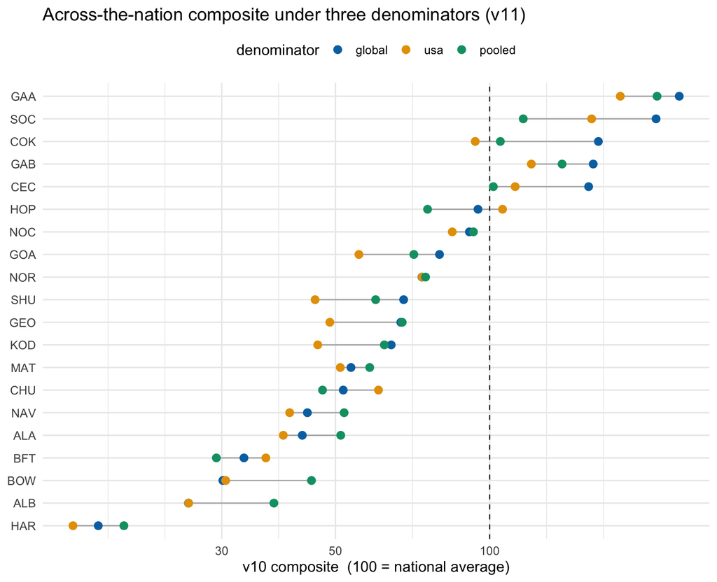

```r
if (has_v10) {
  den <- tab |> select(zone_key, global, usa, pooled) |>
    pivot_longer(-zone_key, names_to = "denominator", values_to = "score") |>
    mutate(zone_key = factor(zone_key, levels = tab$zone_key[order(tab$global, na.last = FALSE)]),
           denominator = factor(denominator, c("global", "usa", "pooled")))
  # Okabe-Ito: colour-blind safe
  pal <- c(global = "#0072B2", usa = "#E69F00", pooled = "#009E73")
  g <- ggplot(den, aes(score, zone_key, colour = denominator)) +
    geom_line(aes(group = zone_key), colour = "grey70", linewidth = 0.5, na.rm = TRUE) +
    geom_vline(xintercept = 100, linetype = "dashed", linewidth = 0.4) +
    geom_point(size = 2.6, na.rm = TRUE) +
    scale_colour_manual(values = pal) +
    labs(x = "v10 composite  (100 = national average)", y = NULL, colour = "denominator",
         title = glue("Across-the-nation composite under three denominators ({vb})")) +
    theme_minimal(base_size = 12) + theme(legend.position = "top")
  # log axis when every score is positive (a concentration index spans orders of magnitude)
  if (all(den$score > 0, na.rm = TRUE)) g <- g + scale_x_log10()
  g
}
```

### 6.6 Method flags

What the release states about how v10 was built (`release_method`).

```r
if (has_v10 && DBI::dbExistsTable(con_b, "release_method")) {
  dbGetQuery(con_b, "SELECT method_key, value, description FROM release_method ORDER BY method_key") |>
    knitr::kable(caption = glue("release_method of {vb}"))
} else if (has_v10) cat(glue("`{vb}` has no `release_method` table.\n"))
```

release_method of v11

| method_key | value | description |
| --- | --- | --- |
| components_labels | v11 | Which component names the manifest shows: v10 (Primary Producers, Primary productivity) or v11 (Flora, Productivity; data/components.csv, msens::component_label()) |
| prev | v10 | The release whose merge and within-ecoregion scoring this version keeps unchanged |
| share_components | bird,coral,fish,invertebrate,mammal,primary_producer,turtle | The scored components; v8’s taxonomy-based categories (no ‘other’); primary productivity joins as primprod_v10 |
| share_denom | global | The headline denominator of each species’ share: global (its whole modelled range), usa (its US distribution), pooled (no per-species normalization); the other two are written beside it |
| share_floor_strip | off | Whether the floored (val = 1) cells of the premultiplied sea turtles are zeroed on both sides of the share (off = kept, the surface stays continuous) |
| share_kappa_pct | 5 | A zone component is reportable only if its scored cells cover at least this percent of the zone’s area (area-weighted); below it there is no score, never a zero |
| share_metrics | on | The across-the-nation score family (each species’ risk-weighted share of its range per km2 against the national average = 100) computed beside the within-ecoregion metrics (v8: off) |

## 7 v11 attribution: which flag moved which score

v11 changes the method in eight independent ways, each a flag in `libs/vars.R` (`vgpm_integrated`, `turtle_suit`, `turtle_rule`, `occ_rule`, `region_weight`, `fold_density`, `components_v11`, `nc_atl_source`). The **control** run has every flag at its v10 value (so it reproduces v10); the **candidate** has every flag on. Each other run is the candidate with **one** flag back at its control value (`no_<flag>`, and `nc_atl_2018` for the Atlantic bird source), so the candidate minus that run is what the flag owns. `scripts/attribution_runs.sh` makes the runs and `snapshot_scores.qmd` writes each run’s zone scores to `data/v11/attribution/{variant}.parquet`; this section reads whatever of that set exists, says which runs are missing, and computes every number below from the files. It reads no `sdm.duckdb`.

```r
# the registry of variants and their single flag swaps is PARSED from the runner, so it cannot drift
att_dir <- here::here("data/v11/attribution")
runs_sh <- readLines(here::here("scripts/attribution_runs.sh"), warn = FALSE)
sh_get  <- function(key) sub(sprintf('^%s="([^"]*)".*$', key), "\\1", grep(sprintf('^%s="', key), runs_sh, value = TRUE))[1]   # a trailing comment is allowed
kv      <- strsplit(strsplit(sh_get("FULL"), " ")[[1]], "=")
cand_kv <- tibble(flag = tolower(sapply(kv, `[`, 1)), candidate = sapply(kv, `[`, 2))
variants_all <- strsplit(sh_get("VARIANTS"), " ")[[1]]
variants_extra <- strsplit(sh_get("EXTRA_VARIANTS"), " ")[[1]]   # follow-ups on the candidate (full2023_cal = + FOLD_DENSITY_CAL=mass), not in --all
variants_extra <- variants_extra[!is.na(variants_extra) & nzchar(variants_extra)]
sw <- regmatches(runs_sh, regexec('^\\s*(\\w+)\\)\\s+echo "\\$\\{FULL/(\\w+)=([^/]+)/\\w+=([^}]+)\\}"', runs_sh, perl = TRUE))
sw <- sw[lengths(sw) == 5]
# the runner spells booleans 0/1, the snapshots TRUE/FALSE
bool <- \(x) ifelse(x == "1", "TRUE", ifelse(x == "0", "FALSE", x))
swaps <- tibble(variant = sapply(sw, `[`, 2), flag = tolower(sapply(sw, `[`, 3)),
                on = bool(sapply(sw, `[`, 4)), off = bool(sapply(sw, `[`, 5)))

# the component labels (v11 names: Flora, Productivity) by component stem
comp_lab <- readr::read_csv(here::here("data/components.csv"), show_col_types = FALSE) |>
  select(stem = key, label, label_v10)

att_files <- list.files(att_dir, "\\.parquet$", full.names = TRUE)
att <- if (length(att_files)) bind_rows(lapply(att_files, arrow::read_parquet)) else tibble()
flag_cols <- setdiff(names(att), c("ver", "variant", "zone_set_key", "zone_fld", "zone_value", "metric_key", "val"))
# a snapshot taken before a flag existed lacks its column: that flag was at its control value then
if (nrow(att)) {
  if (!"nc_atl_source" %in% names(att)) att$nc_atl_source <- NA_character_
  if (!"fold_density_cal" %in% names(att)) att$fold_density_cal <- NA_character_
  if (!"share_basis" %in% names(att)) att$share_basis <- NA_character_
  if (!"range_fill" %in% names(att)) att$range_fill <- NA_character_
  att <- att |> mutate(nc_atl_source = coalesce(nc_atl_source, "2018"), fold_density_cal = coalesce(fold_density_cal, "none"),
                       share_basis = coalesce(share_basis, "taxon"), range_fill = coalesce(range_fill, "er"))   # SHARE_BASIS / RANGE_FILL (2026-11-02)
  flag_cols <- union(flag_cols, c("share_basis", "range_fill"))
}
present <- unique(att$variant)

cand <- c("full2023", "full")[c("full2023", "full") %in% present][1]
has_att <- length(present) > 0 && "control" %in% present && !is.na(cand)
cand_note <- if (!has_att) {
  "The attribution needs at least `control` and a candidate (`full2023` or `full`); the section is skipped."
} else if (cand == "full") {
  "`full2023` (the candidate) is not yet snapshotted: every comparison below uses **`full`** (every flag on, the 2018 Atlantic bird source) as the candidate until it exists."
} else {
  "The candidate is **`full2023`**; `full` (the same with the 2018 Atlantic bird source) is shown as a run of its own."
}
cat(cand_note, "\n")
```

The candidate is **`full2023`**; `full` (the same with the 2018 Atlantic bird source) is shown as a run of its own.

### 7.1 Variants

```r
if (has_att) {
  flag_of <- att |> distinct(variant, across(all_of(flag_cols))) |> mutate(across(everything(), as.character))
  cand_flags <- flag_of[flag_of$variant == cand, flag_cols, drop = FALSE]
  differs <- function(v) {
    if (v %in% present) {
      f <- flag_of[flag_of$variant == v, flag_cols, drop = FALSE]
      d <- flag_cols[unlist(f[1, ]) != unlist(cand_flags[1, ])]
      if (!length(d)) return(if (v == cand) "(the candidate)" else "(none)")
      paste(sprintf("%s=%s", d, unlist(f[1, d])), collapse = ", ")
    } else if (v %in% swaps$variant) {
      s <- swaps[swaps$variant == v, ]
      sprintf("%s=%s", s$flag, s$off)
    } else if (v == "full2023") "(the candidate: every flag on, nc_atl_source=2023)" else "?"
  }
  vt <- tibble(variant = unique(c("control", "full", variants_all, variants_extra))) |>
    mutate(role = case_when(variant == cand ~ "candidate", variant == "control" ~ "control (== v10)",
                            variant %in% swaps$variant ~ "one flag at its control value",
                            variant %in% variants_extra ~ "the candidate + a follow-up setting",
                            TRUE ~ "all flags on"),
           `differs from the candidate` = sapply(variant, differs),
           status = ifelse(variant %in% present, "present", "MISSING"),
           `zone-metric rows` = sapply(variant, \(v) sum(att$variant == v)))
  miss <- vt$variant[vt$status == "MISSING"]
  knitr::kable(vt, caption = glue("{sum(vt$status == 'present')} of {nrow(vt)} variants present"))
}
```

16 of 17 variants present

| variant | role | differs from the candidate | status | zone-metric rows |
| --- | --- | --- | --- | --- |
| control | control (== v10) | vgpm_integrated=FALSE, turtle_suit=am, turtle_rule=turtle, occ_rule=FALSE, region_weight=FALSE, fold_density=FALSE, components_v11=FALSE, nc_atl_source=2018 | present | 5873 |
| full | all flags on | ? | MISSING | 0 |
| full2023 | candidate | (the candidate) | present | 5812 |
| no_vgpm | one flag at its control value | vgpm_integrated=FALSE | present | 5812 |
| no_components | one flag at its control value | components_v11=FALSE | present | 5812 |
| no_turtle_rule | one flag at its control value | turtle_rule=turtle | present | 5788 |
| no_occ_rule | one flag at its control value | occ_rule=FALSE | present | 5873 |
| no_region_weight | one flag at its control value | region_weight=FALSE | present | 5812 |
| no_turtle_suit | one flag at its control value | turtle_suit=am | present | 5812 |
| no_fold_density | one flag at its control value | fold_density=FALSE | present | 5812 |
| nc_atl_2018 | one flag at its control value | nc_atl_source=2018 | present | 5812 |
| full2023_cal | the candidate + a follow-up setting | fold_density_cal=mass | present | 5812 |
| full2023_cal_suit | the candidate + a follow-up setting | fold_density_cal=suit | present | 5812 |
| full2023_basis | the candidate + a follow-up setting | share_basis=cell, range_fill=presence | present | 5812 |
| full2023_basis_er | the candidate + a follow-up setting | share_basis=cell | present | 5812 |
| full2023_basis_mean | the candidate + a follow-up setting | share_basis=cell, range_fill=mean | present | 5812 |
| v11 | the candidate + a follow-up setting | fold_density_cal=suit, share_basis=cell, range_fill=mean | present | 5812 |

```r
if (has_att) cat(if (length(miss)) glue("**Missing variants:** {paste0('`', miss, '`', collapse = ', ')}. Their flags have no attribution row below until `scripts/attribution_runs.sh` has run them and `snapshot_scores` has written the file; every table lists only what exists.\n")
                 else "All variants are present.\n")
```

**Missing variants:** `full`. Their flags have no attribution row below until `scripts/attribution_runs.sh` has run them and `snapshot_scores` has written the file; every table lists only what exists.

```r
if (has_att) {
  PA <- "programarea_key"
  att_pa <- att |> filter(zone_fld == PA)
  m_nat <- "score_v10_equalweights_global"
  m_eco <- grep("^score_.*ecoregion", unique(att_pa$metric_key), value = TRUE)[1]
  vec <- function(v, metric, d = att_pa) {
    x <- d[d$variant == v & d$metric_key == metric, ]
    setNames(x$val, x$zone_value)
  }
  area_nm <- function(k) if (exists("pa") && "zone_name" %in% names(pa)) pa$zone_name[match(k, pa$zone_key)] else NA_character_
  # one-flag variants that exist, in the runner's order, with the flag each owns
  singles <- swaps |> filter(variant %in% present, variant %in% variants_all) |>
    mutate(ord = match(variant, variants_all)) |> arrange(ord)
  # x, y = named vectors by area; deltas on the areas where both exist
  delta_stats <- function(x, y) {
    k <- intersect(names(x), names(y)); k <- k[!is.na(x[k]) & !is.na(y[k])]
    if (!length(k)) return(tibble(areas = 0L, `mean |Δ|` = NA_real_, `max |Δ|` = NA_real_, `at` = NA_character_, r = NA_real_, `Spearman ρ` = NA_real_))
    d <- abs(y[k] - x[k])
    tibble(areas = length(k), `mean |Δ|` = mean(d), `max |Δ|` = max(d), `at` = k[which.max(d)],
           r = if (length(k) > 2) cor(x[k], y[k]) else NA_real_,
           `Spearman ρ` = if (length(k) > 2) cor(x[k], y[k], method = "spearman") else NA_real_)
  }
  runs_vs_cand <- setdiff(intersect(c("control", "full", singles$variant), present), cand)
  mets <- c(national = m_nat, `ecoregion-rescaled` = m_eco)
  cat(glue("Program-Area composites: national `{m_nat}`; ecoregion-rescaled `{m_eco}`.\n"))
}
```

Program-Area composites: national `score_v10_equalweights_global`; ecoregion-rescaled `score_extriskspcat_primprod_ecoregionrescaled_equalweights`.

### 7.2 Headline attribution

Each row compares one run with the candidate on the 20 Program Areas (areas where both runs have a score): the mean and maximum absolute difference, the area of the maximum, and the Pearson r and Spearman ρ between the two sets of scores. The **control** row is the whole change (v10 → candidate); each `no_<flag>` row is what removing that one flag does. The national composite is the v10 concentration index (100 = national average); the ecoregion-rescaled composite is a 0–100 index, so their Δ are on different scales.

```r
if (has_att) {
  for (nm in names(mets)) {
    mm <- mets[[nm]]
    cat(glue("\n\n**{nm} composite** (`{mm}`)\n\n"))
    h <- purrr::map_dfr(runs_vs_cand, \(v) bind_cols(tibble(`run vs candidate` = v), delta_stats(vec(cand, mm), vec(v, mm)))) |>
      left_join(swaps |> select(`run vs candidate` = variant, flag), by = "run vs candidate") |>
      mutate(`flag it removes` = ifelse(is.na(flag), ifelse(`run vs candidate` == "control", "all", ""), flag), .after = 1) |>
      select(-flag) |>
      mutate(across(c(`mean |Δ|`, `max |Δ|`), \(x) round(x, 2)), across(c(r, `Spearman ρ`), \(x) round(x, 3)))
    if (nrow(h)) print(knitr::kable(h, caption = glue("{nm}: runs vs the candidate `{cand}`"))) else cat("No run to compare yet.\n")
  }
}
```

**national composite** (`score_v10_equalweights_global`)

national: runs vs the candidate `full2023`

| run vs candidate | flag it removes | areas | mean \|Δ\| | max \|Δ\| | at | r | Spearman ρ |
| --- | --- | --- | --- | --- | --- | --- | --- |
| control | all | 20 | 20.57 | 48.53 | GAB | 0.928 | 0.940 |
| no_vgpm | vgpm_integrated | 20 | 6.17 | 28.71 | HOP | 0.991 | 0.988 |
| no_components | components_v11 | 20 | 0.00 | 0.00 | GAA | 1.000 | 1.000 |
| no_turtle_rule | turtle_rule | 20 | 0.54 | 3.65 | GAA | 1.000 | 0.998 |
| no_occ_rule | occ_rule | 20 | 1.46 | 3.89 | GOA | 1.000 | 0.997 |
| no_region_weight | region_weight | 20 | 7.35 | 15.37 | NOR | 0.993 | 0.970 |
| no_turtle_suit | turtle_suit | 20 | 2.26 | 23.92 | GAA | 0.996 | 0.998 |
| no_fold_density | fold_density | 20 | 3.66 | 19.57 | SOC | 0.995 | 0.995 |
| nc_atl_2018 | nc_atl_source | 20 | 0.59 | 1.61 | SOC | 1.000 | 1.000 |

**ecoregion-rescaled composite** (`score_extriskspcat_primprod_ecoregionrescaled_equalweights`)

ecoregion-rescaled: runs vs the candidate `full2023`

| run vs candidate | flag it removes | areas | mean \|Δ\| | max \|Δ\| | at | r | Spearman ρ |
| --- | --- | --- | --- | --- | --- | --- | --- |
| control | all | 20 | 2.95 | 9.15 | SHU | 0.921 | 0.789 |
| no_vgpm | vgpm_integrated | 20 | 0.18 | 0.59 | COK | 1.000 | 0.998 |
| no_components | components_v11 | 20 | 0.00 | 0.00 | HOP | 1.000 | 1.000 |
| no_turtle_rule | turtle_rule | 20 | 2.09 | 10.51 | SHU | 0.943 | 0.842 |
| no_occ_rule | occ_rule | 20 | 1.29 | 6.92 | ALA | 0.976 | 0.904 |
| no_region_weight | region_weight | 20 | 0.34 | 1.01 | NOR | 0.999 | 0.994 |
| no_turtle_suit | turtle_suit | 20 | 1.43 | 7.54 | GOA | 0.964 | 0.901 |
| no_fold_density | fold_density | 20 | 0.64 | 2.94 | GAB | 0.997 | 0.989 |
| nc_atl_2018 | nc_atl_source | 20 | 0.19 | 3.43 | GAB | 0.997 | 0.985 |

#### 7.2.1 Per Program Area: the delta each flag owns

For each Program Area: the candidate’s score, the control’s, and the delta each flag owns (candidate minus the run without that flag). **sum of flag deltas** adds the single-flag deltas of the flags present; **candidate − control** is the whole change. The difference between the two is the **interaction**: what the flags do together that none does alone (or the flags whose run is still missing).

```r
area_tab <- function(mm) {
  ck <- vec(cand, mm); k0 <- vec("control", mm)
  keys <- names(ck)
  out <- tibble(`Program Area` = keys, Name = area_nm(keys), candidate = unname(ck), control = unname(k0[keys]))
  for (i in seq_len(nrow(singles))) out[[singles$flag[i]]] <- unname(ck[keys] - vec(singles$variant[i], mm)[keys])
  fl <- if (nrow(singles)) singles$flag else character()
  out |> mutate(`sum of flag deltas` = if (length(fl)) rowSums(across(all_of(fl)), na.rm = TRUE) else NA_real_,
                `candidate − control` = candidate - control,
                interaction = `candidate − control` - `sum of flag deltas`) |>
    arrange(desc(candidate))
}
area_dt <- function(nm) {
  at <- area_tab(mets[[nm]])
  DT::datatable(at, rownames = FALSE, options = list(pageLength = 20, dom = "t", scrollX = TRUE),
                caption = glue("{nm}: candidate `{cand}`, control, and the delta each flag owns (candidate minus the run without it); flags present: ",
                               "{if (nrow(singles)) paste(singles$flag, collapse = ', ') else 'none'}")) |>
    DT::formatRound(setdiff(names(at), c("Program Area", "Name")), 1)
}
```

**National composite**

```r
if (has_att) area_dt("national")
```

| Program Area | Name | candidate | control | vgpm_integrated | components_v11 | turtle_rule | occ_rule | region_weight | turtle_suit | fold_density | nc_atl_source | sum of flag deltas | candidate − control | interaction |
| --- | --- | --- | --- | --- | --- | --- | --- | --- | --- | --- | --- | --- | --- | --- |
| GAA | GOA Program Area A | 234.1025982716222 | 253.217322028179 | 3.781289994037905 | -1.477928890381008e-11 | 3.64926219309362 | -2.67096780715525 | 6.559183390007092 | 23.92140484109004 | -6.970453789051589 | 0.275329395103256 | 28.54504821711029 | -19.11472375655686 | -47.65977197366715 |
| SOC | Southern California | 207.5659185757782 | 166.4892137927905 | 3.540836541396118 | -1.080024958355352e-11 | 0.7446956629083274 | 3.109882507441995 | 14.71087017320704 | -4.469255525161003 | 19.56658341172707 | 1.606651884121504 | 38.81026465563025 | 41.07670478298775 | 2.266440127357498 |
| GAB | GOA Program Area B | 175.0528226310654 | 126.5187708338388 | 1.717839395389774 | -1.139710548159201e-11 | 2.704270923202188 | 3.001090423420834 | 7.552302884909722 | 9.133735029889124 | 2.550604462975258 | 0.1975164128409688 | 26.85735953261647 | 48.5340517972266 | 21.67669226461012 |
| COK | Cook Inlet | 164.310401478834 | 179.4251784412668 | -8.975280900602058 | -9.066525308298878e-12 | 0.01991683267783628 | -2.267121390396142 | 1.97379892441333 | 0.005910511468158575 | -3.581904472407643 | 1.100922932860954 | -11.72375756199463 | -15.11477696243281 | -3.391019400438182 |
| CEC | Central California | 157.2614858579341 | 124.3988605389299 | 3.973071338782262 | -7.702283255639486e-12 | 1.564199533505104 | 2.146554004659748 | 10.67576585896532 | -3.735423599331909 | 13.16215707977028 | 1.545841895094071 | 29.33216611143718 | 32.86262531900418 | 3.530459207567006 |
| NOC | Northern California | 90.82611017644527 | 70.32158459755594 | 3.172685257026245 | -3.836930773104541e-12 | 2.08315507089965 | 1.243974753207638 | 6.039836453199271 | -3.81272362003692 | 10.65355611609786 | 1.304683377686402 | 20.68516740807631 | 20.50452557888933 | -0.1806418291869818 |
| HOP | Hope Basin | 89.1848094946378 | 113.5392649641133 | -28.71485019126597 | -4.050093593832571e-12 | -2.145839061995503e-12 | -0.6026501421294199 | 8.026253142105958 | -4.263256414560601e-13 | -2.667129412774855 | 1.210036437067416 | -22.74834016700349 | -24.35445546947545 | -1.606115302471963 |
| GOA | Gulf of Alaska | 80.89725512590482 | 97.96492712492794 | -2.509092178822002 | -4.035882739117369e-12 | 0.006455174854480106 | -3.894542771571665 | -4.721807883106223 | -0.01831122912051342 | -1.570608666735197 | 0.6093133191692459 | -12.09859423533591 | -17.06767199902312 | -4.96907776368721 |
| NOR | Norton Basin | 73.80700551433586 | 118.794600288962 | -22.95813671809789 | -3.211653165635653e-12 | -1.691091711109038e-12 | -0.493043378081893 | -15.37397179460642 | -3.410605131648481e-13 | -1.778777519531189 | 0.5410702216851888 | -40.06285918863745 | -44.98759477462616 | -4.924735585988714 |
| SHU | Shumagin | 66.80185720473087 | 72.93252659459078 | 0.1109038315161257 | -3.367972567502875e-12 | 0.042563299865364 | -3.212834787158485 | -1.039981492261248 | 0.02678429330734389 | -1.585056374394782 | 0.4259986621091514 | -5.231622567019897 | -6.130669389859918 | -0.8990468228400204 |

[output cut: 10 more lines]

**Ecoregion-rescaled composite**

```r
if (has_att) area_dt("ecoregion-rescaled")
```

| Program Area | Name | candidate | control | vgpm_integrated | components_v11 | turtle_rule | occ_rule | region_weight | turtle_suit | fold_density | nc_atl_source | sum of flag deltas | candidate − control | interaction |
| --- | --- | --- | --- | --- | --- | --- | --- | --- | --- | --- | --- | --- | --- | --- |
| HOP | Hope Basin | 48.17783670434302 | 48.43066882964051 | 0.3964736918305292 | 1.271470399899499e-05 | -1.587916545275903e-05 | -1.216156742274961 | -0.1125765778464896 | -1.726970146620488e-05 | -0.1119003505333183 | -2.616600227867139e-05 | -1.044206578989439 | -0.2528321252974877 | 0.7913744536919509 |
| COK | Cook Inlet | 46.71173377020246 | 47.92639925738253 | -0.5862213241320546 | -7.105427357601002e-15 | 4.58355587134502 | -2.34088192088268 | 0.8747702117596177 | 1.409212146956754 | -0.9636158035929583 | 7.105427357601002e-15 | 2.976819181453699 | -1.214665487180071 | -4.19148466863377 |
| GAA | GOA Program Area A | 33.22866855593302 | 32.87440870698386 | -0.001352999123611198 | -5.920040280216199e-08 | -3.111055827049491 | 0.5026336434755194 | -0.6327510530370333 | -1.567037636592225 | 0.4109583269435433 | 0.3628945837328743 | -4.035711020850826 | 0.3542598489491553 | 4.389970869799981 |
| GEO | St. George Basin | 30.97216132927019 | 28.93767009431623 | 0.4756468568220065 | -3.126627486693678e-06 | -4.689941231816874e-06 | 4.011707717246971 | -0.07714357914079173 | -4.68994121760602e-06 | 0.2060794339562904 | -9.37988244587018e-06 | 4.616268542492094 | 2.034491234953954 | -2.58177730753814 |
| SHU | Shumagin | 28.53752461207716 | 19.3900073995149 | 0.05808756765449274 | 3.552713678800501e-15 | 10.51401640797013 | 1.156903155766816 | 0.1986954161171148 | 6.433691232083802 | 0.7746793744050606 | -3.552713678800501e-15 | 19.13607315399742 | 9.14751721256226 | -9.988555941435159 |
| KOD | Kodiak | 28.32238735001884 | 22.18680683407273 | -0.06128076718831821 | 1.77635683940025e-14 | 8.91534398407141 | 0.9155998796622953 | 0.03823819500286874 | 3.600689579991702 | 1.160482940977491 | 3.552713678800501e-15 | 14.56907381251747 | 6.135580515946106 | -8.433493296571363 |
| NOR | Norton Basin | 27.40417644691945 | 29.34669791332733 | 0.3398340083507918 | -3.603984765732093e-06 | -1.959724493616477e-05 | 0.8402870878466402 | -1.009120306727365 | -1.783972458113681e-05 | -0.2342858298061934 | -1.248203177084406e-05 | -0.06333856332217991 | -1.942521466407875 | -1.879182903085695 |
| CHU | Chukchi Sea | 27.27405046739884 | 23.10883997576983 | -0.1167800217492605 | 5.012148616145851e-06 | 1.151598166160284e-06 | 0.119353041525617 | 0.2841983347796386 | 6.089030762268521e-06 | -0.004502967369806044 | 3.778257664066587e-06 | 0.2822844182213977 | 4.165210491629015 | 3.882926073407617 |
| GAB | GOA Program Area B | 25.97848269113357 | 18.13653764839079 | 0.0001725923308200095 | -7.105427357601002e-15 | -1.468975619503805 | 0.8696990035841701 | 0.436768224116328 | -3.431811349922498 | 2.938289722777849 | 3.433307581817608 | 2.777450155200466 | 7.841945042742786 | 5.06449488754232 |
| GOA | Gulf of Alaska | 25.68564911195683 | 32.07838765282859 | -0.1191828003430544 | -1.4210854715202e-14 | 1.455743503316455 | -4.644061884195921 | -0.5384180335510003 | -7.541451356412679 | 1.557607642861058 | 5.653530372740079e-07 | -9.829762362972119 | -6.392738540871754 | 3.437023822100365 |

[output cut: 10 more lines]

### 7.3 Components

The same comparison for each component score under the national scoring (`extrisk_{category}_v10_global` and `primprod_v10`), over the Program Areas: per flag and component, the mean and maximum |Δ| where both runs report it, and the Program Areas where the flag **adds** the component (the candidate reports it, the run without the flag does not) or **removes** it (the reverse). An absent row is a component with too little coverage in that area to report under the 5 % floor, never a zero. Labels are the v11 names from `data/components.csv`.

```r
if (has_att) {
  cmet <- grep("^(extrisk_.*_v10_global|primprod_v10)$", unique(att_pa$metric_key), value = TRUE)
  cstem <- ifelse(cmet == "primprod_v10", "primprod", sub("^extrisk_(.*)_v10_global$", "\\1", cmet))
  clab  <- comp_lab$label[match(cstem, comp_lab$stem)]
  clab  <- ifelse(is.na(clab), cstem, clab)
  runs_c <- c(control = "control", setNames(singles$variant, singles$flag))
  runs_c <- runs_c[runs_c %in% present & runs_c != cand]
  ct <- purrr::map_dfr(names(runs_c), \(fl) purrr::map_dfr(seq_along(cmet), \(i) {
    x <- vec(cand, cmet[i]); y <- vec(runs_c[[fl]], cmet[i])
    s <- delta_stats(x, y)
    tibble(`flag removed` = fl, Component = clab[i], `both report` = s$areas,
           `mean |Δ|` = s$`mean |Δ|`, `max |Δ|` = s$`max |Δ|`, `at` = s$at,
           `flag adds it in` = paste(sort(setdiff(names(x), names(y))), collapse = " "),
           `flag removes it in` = paste(sort(setdiff(names(y), names(x))), collapse = " "))
  }))
  if (nrow(ct)) {
    wide <- ct |> select(`flag removed`, Component, `mean |Δ|`) |>
      mutate(`mean |Δ|` = round(`mean |Δ|`, 2)) |> pivot_wider(names_from = Component, values_from = `mean |Δ|`)
    print(knitr::kable(wide, caption = glue("Mean |Δ| per Program Area, candidate `{cand}` minus the run without the flag ('control' = every flag removed)")))
  } else cat("No run to compare yet.\n")
}
```

```
Table: Mean |Δ| per Program Area, candidate `full2023` minus the run without the flag ('control' = every flag removed)

|flag removed    | Seabirds| Corals|  Fish| Invertebrates| Marine Mammals| Flora| Sea Turtles| Productivity|
|:---------------|--------:|------:|-----:|-------------:|--------------:|-----:|-----------:|------------:|
|control         |    29.07|   2.43| 23.96|         10.42|          52.57|  3.29|       45.07|        44.67|
|vgpm_integrated |     0.00|   0.00|  0.00|          0.00|           0.00|  0.00|        0.00|        44.67|
|components_v11  |     0.00|   0.00|  0.00|          0.00|           0.00|  0.00|        0.00|         0.00|
|turtle_rule     |     0.00|   0.00|  0.00|          0.00|           0.00|  0.00|        9.65|         0.00|
|occ_rule        |     0.76|   1.09|  1.72|          4.11|           0.73|  2.00|       12.75|         0.00|
|region_weight   |    20.76|   1.53|  6.00|          7.03|          28.15|  3.31|       24.24|         0.00|
|turtle_suit     |     0.00|   0.00|  0.00|          0.00|           0.00|  0.00|       40.13|         0.00|
|fold_density    |    10.10|   0.00|  0.00|          0.00|          18.63|  0.00|        0.03|         0.00|
|nc_atl_source   |     4.48|   0.00|  0.00|          0.00|           0.00|  0.00|        0.00|         0.00|
```

```r
if (has_att && exists("ct") && nrow(ct)) {
  DT::datatable(ct |> mutate(across(c(`mean |Δ|`, `max |Δ|`), \(x) round(x, 2))), rownames = FALSE, filter = "top",
                options = list(pageLength = 20, scrollX = TRUE),
                caption = glue("Flag × component over Program Areas. flag adds it in = areas where `{cand}` reports the component and the run without the flag does not; flag removes it in = the reverse"))
}
```

| flag removed | Component | both report | mean \|Δ\| | max \|Δ\| | at | flag adds it in | flag removes it in |
| --- | --- | --- | --- | --- | --- | --- | --- |
| control | Seabirds | 20 | 29.07 | 99.22 | NOC |  |  |
| control | Corals | 20 | 2.43 | 20.47 | GAA |  |  |
| control | Fish | 20 | 23.96 | 91.3 | COK |  |  |
| control | Invertebrates | 20 | 10.42 | 57.88 | GAA |  |  |
| control | Marine Mammals | 20 | 52.57 | 176.43 | SOC |  |  |
| control | Flora | 20 | 3.29 | 8.79 | COK |  |  |
| control | Sea Turtles | 9 | 45.07 | 268.18 | GAB |  | ALA |
| control | Productivity | 20 | 44.67 | 201 | HOP |  |  |
| vgpm_integrated | Seabirds | 20 | 0 | 0 | SOC |  |  |
| vgpm_integrated | Corals | 20 | 0 | 0 | GAA |  |  |

[output cut: 62 more lines]

### 7.4 The occurrence rule’s reach

The occurrence rule (`occ_rule`) gates a species out of an ecoregion where records are significantly and materially fewer than elsewhere; `region_weight` downweights it by its encounter weight `w` there. `data/v11/zone_exclusions_occ.csv` holds the gated pairs and `data/v11/zone_weights_occ.csv` the weighted ones (a gated pair is `w = 0` there); both come from the exploration notebook. The denominator is each component’s species count in the ecoregion (`extrisk_{category}_n_species`) of the run without the rule, so the percentage is the share of the component’s species there that the rule touches.

```r
f_ex <- here::here("data/v11/zone_exclusions_occ.csv"); f_w <- here::here("data/v11/zone_weights_occ.csv")
has_occ <- file.exists(f_ex) && file.exists(f_w)
if (!has_occ) cat("The occurrence-rule CSVs are not on disk: this subsection is skipped.\n")
if (has_occ) {
  ex <- readr::read_csv(f_ex, show_col_types = FALSE)
  wt <- readr::read_csv(f_w,  show_col_types = FALSE)
  base_run <- c("no_occ_rule", "control")[c("no_occ_rule", "control") %in% present][1]
  den <- att |> filter(zone_fld == "ecoregion_key", variant == base_run, grepl("^extrisk_.*_n_species$", metric_key)) |>
    transmute(ecoregion = zone_value, sp_cat = sub("^extrisk_(.*)_n_species$", "\\1", metric_key), n_in_zone = val)
  gated <- ex |> distinct(mdl_key, ecoregion = zone_key, sp_cat) |> count(ecoregion, sp_cat, name = "gated")
  wtd   <- wt |> filter(w > 0, w < 1) |> group_by(ecoregion = zone_key, sp_cat) |>
    summarise(weighted = n_distinct(mdl_key), `median w` = median(w), .groups = "drop")
  reach <- full_join(gated, wtd, by = c("ecoregion", "sp_cat")) |>
    left_join(den, by = c("ecoregion", "sp_cat")) |>
    mutate(across(c(gated, weighted), \(x) coalesce(x, 0L)),
           affected = gated + weighted,
           `% of the component's species` = 100 * affected / n_in_zone,
           Component = coalesce(comp_lab$label[match(sp_cat, comp_lab$stem)], sp_cat)) |>
    arrange(ecoregion, sp_cat)
  cat(glue("Species counts from `{base_run}`; {nrow(ex)} gated and {sum(wt$w > 0 & wt$w < 1)} downweighted ",
           "(species, ecoregion) pairs over {n_distinct(c(ex$mdl_key, wt$mdl_key))} species.\n"))
}
```

Species counts from `no_occ_rule`; 3817 gated and 8335 downweighted (species, ecoregion) pairs over 6066 species.

```r
if (has_occ && nrow(reach)) {
  reach |> transmute(Ecoregion = ecoregion, Component, `species in zone` = n_in_zone, gated, weighted,
                     `median w` = round(`median w`, 3), `% affected` = round(`% of the component's species`, 1)) |>
    DT::datatable(rownames = FALSE, filter = "top", options = list(pageLength = 15, scrollX = TRUE),
                  caption = "Occurrence rule: species gated (w = 0) and downweighted (0 < w < 1) per ecoregion and component")
}
```

| Ecoregion | Component | species in zone | gated | weighted | median w | % affected |
| --- | --- | --- | --- | --- | --- | --- |
| CAC | Seabirds | 109 | 2 | 11 | 0.763 | 11.9 |
| CAC | Corals | 72 | 10 | 6 | 0.392 | 22.2 |
| CAC | Fish | 1197 | 110 | 166 | 0.241 | 23.1 |
| CAC | Invertebrates | 2123 | 214 | 135 | 0.48 | 16.4 |
| CAC | Marine Mammals | 44 | 0 | 7 | 0.3 | 15.9 |
| CAC | Flora | 60 | 21 | 2 | 0.354 | 38.3 |
| CAC | Sea Turtles | 4 | 0 | 4 | 0.441 | 100 |
| CBS | Seabirds | 70 | 2 | 22 | 0.425 | 34.3 |
| CBS | Corals | 12 | 3 | 0 |  | 25 |
| CBS | Fish | 111 | 5 | 21 | 0.342 | 23.4 |

[output cut: 69 more lines]

```r
if (has_occ && nrow(reach)) {
  reach |> transmute(Ecoregion = ecoregion, Component, pct = round(`% of the component's species`, 1)) |>
    pivot_wider(names_from = Component, values_from = pct) |>
    knitr::kable(caption = "Share (%) of each component's species in the ecoregion that the rule gates or downweights")
}
```

Share (%) of each component’s species in the ecoregion that the rule gates or downweights

| Ecoregion | Seabirds | Corals | Fish | Invertebrates | Marine Mammals | Flora | Sea Turtles |
| --- | --- | --- | --- | --- | --- | --- | --- |
| CAC | 11.9 | 22.2 | 23.1 | 16.4 | 15.9 | 38.3 | 100.0 |
| CBS | 34.3 | 25.0 | 23.4 | 25.7 | 42.1 | NA | NA |
| EBS | 63.0 | 32.5 | 27.4 | 24.1 | 68.4 | 10.5 | 100.0 |
| EGOA | 16.9 | 29.2 | 32.7 | 14.6 | 23.3 | 14.1 | 33.3 |
| GOA | 62.1 | 41.7 | 43.0 | 39.8 | 55.9 | 40.0 | 100.0 |
| HAR | 8.7 | NA | 1.6 | 1.6 | 18.2 | NA | NA |
| NECS | 4.1 | 41.7 | 30.4 | 22.4 | 20.0 | 14.5 | 16.7 |
| PIS | 27.2 | 3.6 | 6.9 | 6.0 | 77.4 | 18.0 | 80.0 |
| PUR | 40.7 | 11.9 | 25.1 | 14.6 | 77.8 | 19.0 | 20.0 |
| SECS | 17.0 | 38.0 | 31.3 | 34.4 | 70.6 | 42.9 | 33.3 |
| WAOR | 23.5 | 28.8 | 33.2 | 20.7 | 15.6 | 24.0 | 100.0 |
| WCGOA | 23.8 | 38.3 | 39.1 | 34.6 | 27.6 | 8.9 | 33.3 |

```r
if (has_occ) {
  mt <- c("mammal", "turtle")
  g <- ex |> filter(sp_cat %in% mt) |>
    transmute(Ecoregion = zone_key, Component = comp_lab$label[match(sp_cat, comp_lab$stem)], Species = scientific_name,
              `Common name` = common_name, w = 0, `n searched` = n_searched, `n occupied` = n_occupied, Reason = reason) |>
    arrange(Component, Species, Ecoregion)
  if (nrow(g)) DT::datatable(g, rownames = FALSE, filter = "top", options = list(pageLength = 10, scrollX = TRUE),
                             caption = glue("Marine mammal and sea turtle pairs gated out ({nrow(g)}; w = 0)"))
}
```

| Ecoregion | Component | Species | Common name | w | n searched | n occupied | Reason |
| --- | --- | --- | --- | --- | --- | --- | --- |
| PUR | Marine Mammals | Balaenoptera acutorostrata | Minke Whale | 0 | 83 | 0 | occurrence rule E: 0 of 83 searched 0.5-degree blocks hold a record (rate 0), against 0.101 in the species' other ecoregions (p = 0.00014) |
| PUR | Marine Mammals | Balaenoptera borealis | Sei Whale | 0 | 83 | 0 | occurrence rule E: 0 of 83 searched 0.5-degree blocks hold a record (rate 0), against 0.0488 in the species' other ecoregions (p = 0.016) |
| NECS | Marine Mammals | Balaenoptera brydei | large form Bryde's whale | 0 | 226 | 0 | occurrence rule E: 0 of 226 searched 0.5-degree blocks hold a record (rate 0), against 0.0383 in the species' other ecoregions (p = 0.00015) |
| SECS | Marine Mammals | Balaenoptera brydei | large form Bryde's whale | 0 | 212 | 0 | occurrence rule E: 0 of 212 searched 0.5-degree blocks hold a record (rate 0), against 0.038 in the species' other ecoregions (p = 0.00027) |
| WCGOA | Marine Mammals | Balaenoptera brydei | large form Bryde's whale | 0 | 113 | 0 | occurrence rule E: 0 of 113 searched 0.5-degree blocks hold a record (rate 0), against 0.0361 in the species' other ecoregions (p = 0.016) |
| NECS | Marine Mammals | Balaenoptera edeni | Bryde’s Whale | 0 | 215 | 0 | occurrence rule E: 0 of 215 searched 0.5-degree blocks hold a record (rate 0), against 0.0166 in the species' other ecoregions (p = 0.027) |
| SECS | Marine Mammals | Balaenoptera edeni | Bryde’s Whale | 0 | 215 | 0 | occurrence rule E: 0 of 215 searched 0.5-degree blocks hold a record (rate 0), against 0.0166 in the species' other ecoregions (p = 0.027) |
| EGOA | Marine Mammals | Balaenoptera musculus | Blue Whale | 0 | 136 | 0 | occurrence rule E: 0 of 136 searched 0.5-degree blocks hold a record (rate 0), against 0.0868 in the species' other ecoregions (p = 4.3e-06) |
| PUR | Marine Mammals | Balaenoptera musculus | Blue Whale | 0 | 83 | 0 | occurrence rule E: 0 of 83 searched 0.5-degree blocks hold a record (rate 0), against 0.0854 in the species' other ecoregions (p = 0.00061) |
| SECS | Marine Mammals | Balaenoptera musculus | Blue Whale | 0 | 215 | 0 | occurrence rule E: 0 of 215 searched 0.5-degree blocks hold a record (rate 0), against 0.0889 in the species' other ecoregions (p = 2e-09) |

[output cut: 28 more lines]

```r
if (has_occ) {
  lo <- wt |> filter(sp_cat %in% c("mammal", "turtle"), w > 0, w < 1) |> arrange(w) |> slice_head(n = 20) |>
    transmute(Ecoregion = zone_key, Component = comp_lab$label[match(sp_cat, comp_lab$stem)], Species = scientific_name,
              `Common name` = common_name, w = signif(w, 3), `n searched` = n_searched, `n occupied` = n_occupied,
              rate = signif(rate, 3), `baseline rate` = signif(p_core, 3))
  if (nrow(lo)) knitr::kable(lo, caption = "The 20 most downweighted marine mammal and sea turtle pairs that are not gated (smallest w > 0)")
}
```

The 20 most downweighted marine mammal and sea turtle pairs that are not gated (smallest w > 0)

| Ecoregion | Component | Species | Common name | w | n searched | n occupied | rate | baseline rate |
| --- | --- | --- | --- | --- | --- | --- | --- | --- |
| PIS | Marine Mammals | Balaenoptera musculus | Blue Whale | 0.0145 | 1121 | 2 | 0.00178 | 0.1230 |
| GOA | Sea Turtles | Dermochelys coriacea | Leatherback Turtle | 0.0192 | 538 | 3 | 0.00558 | 0.2910 |
| CBS | Marine Mammals | Orcinus orca | Killer Whale | 0.0216 | 393 | 1 | 0.00254 | 0.1180 |
| WAOR | Sea Turtles | Caretta caretta | Loggerhead Turtle | 0.0298 | 137 | 1 | 0.00730 | 0.2450 |
| GOA | Marine Mammals | Zalophus californianus | California Sea Lion | 0.0307 | 133 | 3 | 0.02260 | 0.7340 |
| CBS | Marine Mammals | Phocoena phocoena | Harbor Porpoise | 0.0465 | 359 | 7 | 0.01950 | 0.4200 |
| EBS | Marine Mammals | Balaenoptera musculus | Blue Whale | 0.0475 | 443 | 2 | 0.00451 | 0.0951 |
| EBS | Marine Mammals | Berardius bairdii | Baird’s Beaked Whale | 0.0547 | 1036 | 4 | 0.00386 | 0.0705 |
| HAR | Marine Mammals | Delphinapterus leucas | Beluga Whale | 0.0552 | 57 | 1 | 0.01750 | 0.3180 |
| WAOR | Sea Turtles | Chelonia mydas | Green Turtle | 0.0578 | 137 | 1 | 0.00730 | 0.1260 |
| PIS | Marine Mammals | Balaenoptera physalus | Fin Whale | 0.0614 | 702 | 12 | 0.01710 | 0.2780 |
| WAOR | Marine Mammals | Globicephala macrorhynchus | Short-Finned Pilot Whale | 0.0697 | 137 | 1 | 0.00730 | 0.1050 |
| GOA | Marine Mammals | Grampus griseus | Risso’s Dolphin | 0.0701 | 538 | 7 | 0.01300 | 0.1860 |
| PIS | Marine Mammals | Orcinus orca | Killer Whale | 0.0761 | 1121 | 12 | 0.01070 | 0.1410 |
| PUR | Marine Mammals | Stenella coeruleoalba | Striped Dolphin | 0.0785 | 83 | 1 | 0.01200 | 0.1530 |
| PUR | Marine Mammals | Stenella attenuata | Pantropical Spotted Dolphin | 0.0786 | 83 | 1 | 0.01200 | 0.1530 |
| EBS | Marine Mammals | Lagenorhynchus obliquidens | Pacific White-Sided Dolphin | 0.0806 | 341 | 6 | 0.01760 | 0.2180 |
| GOA | Marine Mammals | Ziphius cavirostris | Cuvier’s Beaked Whale | 0.0970 | 538 | 4 | 0.00743 | 0.0766 |
| GOA | Marine Mammals | Phoca largha | Spotted Seal | 0.0991 | 42 | 2 | 0.04760 | 0.4810 |
| GOA | Marine Mammals | Balaenoptera borealis | Sei Whale | 0.1020 | 538 | 3 | 0.00558 | 0.0549 |

### 7.5 Figures

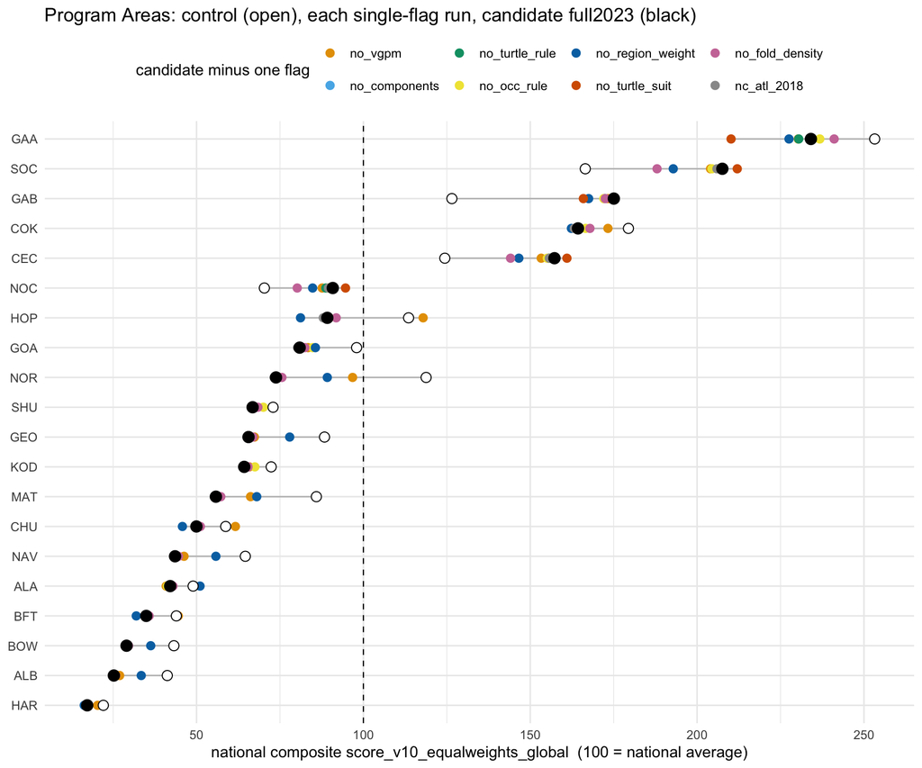

```r
if (has_att) {
  run_ord <- c("control", singles$variant, cand) |> unique() |> intersect(present)
  lp <- purrr::map_dfr(run_ord, \(v) tibble(run = v, area = names(vec(v, m_nat)), score = unname(vec(v, m_nat))))
  area_lv <- names(sort(vec(cand, m_nat)))
  lp <- lp |> mutate(area = factor(area, area_lv), run = factor(run, run_ord))
  # Okabe-Ito for the flag runs; the control is an open circle, the candidate a large black dot
  pal <- setNames(c("#E69F00", "#56B4E9", "#009E73", "#F0E442", "#0072B2", "#D55E00", "#CC79A7", "#999999")[seq_len(nrow(singles))], singles$variant)
  ggplot(lp, aes(score, area)) +
    geom_line(aes(group = area), colour = "grey75", linewidth = 0.5) +
    geom_point(data = filter(lp, run %in% singles$variant), aes(colour = run), size = 2.4) +
    geom_point(data = filter(lp, run == "control"), shape = 21, fill = "white", size = 3) +
    geom_point(data = filter(lp, run == cand), colour = "black", size = 3.4) +
    geom_vline(xintercept = 100, linetype = "dashed", linewidth = 0.4) +
    scale_colour_manual(values = pal, name = "candidate minus one flag") +
    labs(x = glue("national composite {m_nat}  (100 = national average)"), y = NULL,
         title = glue("Program Areas: control (open), each single-flag run, candidate {cand} (black)")) +
    theme_minimal(base_size = 11) + theme(legend.position = "top")
}
```

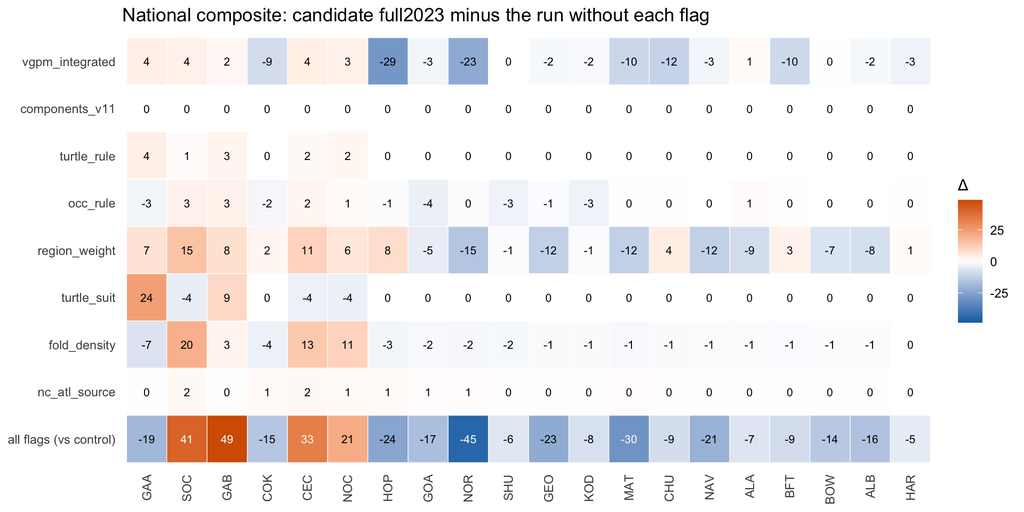

```r
if (has_att && nrow(singles)) {
  hm <- purrr::map_dfr(c(singles$variant, "control"), \(v) {
    x <- vec(cand, m_nat); y <- vec(v, m_nat)
    tibble(flag = if (v == "control") "all flags (vs control)" else singles$flag[match(v, singles$variant)],
           area = names(x), delta = unname(x - y[names(x)]))
  }) |> mutate(area = factor(area, names(sort(vec(cand, m_nat), decreasing = TRUE))),
               flag = factor(flag, rev(unique(flag))))
  lim <- max(abs(hm$delta), na.rm = TRUE)
  ggplot(hm, aes(area, flag, fill = delta)) +
    geom_tile(colour = "white") +
    geom_text(aes(label = ifelse(is.na(delta), "", format(round(delta), trim = TRUE)), colour = abs(delta) > 0.6 * lim), size = 2.8, show.legend = FALSE) +
    scale_colour_manual(values = c(`TRUE` = "white", `FALSE` = "black")) +
    scale_fill_gradient2(low = "#0072B2", mid = "white", high = "#D55E00", midpoint = 0, limits = c(-lim, lim), na.value = "grey90",
                         name = "Δ") +
    labs(x = NULL, y = NULL, title = glue("National composite: candidate {cand} minus the run without each flag")) +
    theme_minimal(base_size = 11) + theme(axis.text.x = element_text(angle = 90, vjust = 0.5, hjust = 1), panel.grid = element_blank())
}
```